# **Loan Default Prediction**

## **Problem Definition**

### **The Context:**

Loan defaults represent a significant risk to the profitability of retail banks, as non-performing assets (NPAs) can substantially impact their bottom line. According to banking industry reports, even a small reduction in default rates can translate to millions of dollars in saved revenue. Currently, the loan approval process is multifaceted and often manual, making it both effort-intensive and susceptible to human error and biases.

By developing a robust loan default prediction model, banks can:

- Reduce the financial risk associated with bad loans/NPAs
- Make the approval process more efficient and consistent (reducing approval time by 40-60%)
- Remove human biases from the decision-making process
- Improve the overall portfolio quality of home equity loans
- Comply with regulatory requirements like the Equal Credit Opportunity Act
- Create a competitive advantage through data-driven decision making
- Free up loan officers to focus on complex cases requiring human judgment

The financial implications of improved loan default prediction are substantial, with potential to increase bank profitability by 15-20% in the consumer credit division.

### **The Objective:**

The primary objectives of this project are to:

- Build a classification model that accurately predicts which clients are likely to default on their home equity loans
- Identify the key features that significantly influence loan default risk
- Establish optimal thresholds for different risk tolerance levels
- Provide actionable recommendations to the bank for improving their loan approval process
- Create a model that is interpretable enough to provide justification for any adverse decisions (rejections)
- Ensure the model follows regulatory guidelines and is free from discriminatory biases
- Develop a framework for continuous model monitoring and improvement
- Quantify the financial impact of the improved prediction model

### **The Key Questions:**

- What customer attributes and loan characteristics are most predictive of default risk?
- How do demographic and financial factors influence the likelihood of loan default?
- Are there specific patterns or customer segments that show higher default rates?
- What interactions between variables significantly impact default probability?
- What is the optimal threshold for approving loans that balances risk and business objectives?
- How can the bank improve their current approval process to minimize defaults while maintaining a healthy loan portfolio?
- What quantifiable impact can an improved model have on the bank's financial performance?
- How do different model types perform on this specific loan default prediction task?
- Which derived features or transformations provide additional predictive power?
- How can we ensure the model remains effective over time with changing economic conditions?

### **The Problem Formulation**:

We are developing a binary classification model to predict whether a loan applicant will default (BAD=1) or repay their loan (BAD=0) based on various applicant characteristics and loan attributes. The model will use historical data from past loan applicants who have been given credit, learning patterns that indicate higher default risk.

The solution must be:

- Accurate in predicting defaults to minimize financial risk
- Interpretable to satisfy regulatory requirements
- Fair and unbiased across different customer segments
- Operationally feasible for integration into the bank's decision process
- Robust to changes in economic conditions and customer demographics
- Capable of providing probability estimates, not just binary decisions
- Designed to balance false positives (denying loans to creditworthy customers) and false negatives (approving loans that will default)

## **Data Description:**

The Home Equity dataset (HMEQ) contains baseline and loan performance information for 5,960 recent home equity loans. The target (BAD) is a binary variable that indicates whether an applicant has ultimately defaulted or has been severely delinquent. This adverse outcome occurred in 1,189 cases (20 percent). 12 input variables were registered for each applicant.

- **BAD:** 1 = Client defaulted on loan, 0 = loan repaid
- **LOAN:** Amount of loan approved.
- **MORTDUE:** Amount due on the existing mortgage.
- **VALUE:** Current value of the property.
- **REASON:** Reason for the loan request. (HomeImp = home improvement, DebtCon= debt consolidation which means taking out a new loan to pay off other liabilities and consumer debts)
- **JOB:** The type of job that loan applicant has such as manager, self, etc.
- **YOJ:** Years at present job.
- **DEROG:** Number of major derogatory reports (which indicates a serious delinquency or late payments).
- **DELINQ:** Number of delinquent credit lines (a line of credit becomes delinquent when a borrower does not make the minimum required payments 30 to 60 days past the day on which the payments were due).
- **CLAGE:** Age of the oldest credit line in months.
- **NINQ:** Number of recent credit inquiries.
- **CLNO:** Number of existing credit lines.
- **DEBTINC:** Debt-to-income ratio (all your monthly debt payments divided by your gross monthly income. This number is one way lenders measure your ability to manage the monthly payments to repay the money you plan to borrow.

## **Import Necessary Libraries and Data**

```python
# Import essential libraries
# Data manipulation and analysis
import pandas as pd
import numpy as np

# Data visualization
import matplotlib.pyplot as plt
import seaborn as sns
import math

# Statistical analysis
from scipy import stats

# Machine learning model selection and evaluation
from sklearn.model_selection import train_test_split, GridSearchCV

# Machine learning models
from sklearn.ensemble import RandomForestClassifier
from sklearn.tree import DecisionTreeClassifier
from sklearn.linear_model import LogisticRegression
from sklearn.ensemble import GradientBoostingClassifier

# Model evaluation metrics
from sklearn.metrics import (
   classification_report,
   confusion_matrix,
   accuracy_score,
   precision_score,
   recall_score,
   roc_auc_score,
   f1_score
)

# Data preprocessing
from sklearn.preprocessing import LabelEncoder, StandardScaler

# Additional utility imports
from sklearn import metrics

from google.colab import drive
drive.mount('/content/drive/')
```

## **Data Overview**

- Reading the dataset
- Understanding the shape of the dataset
- Checking the data types
- Checking for missing values
- Checking for duplicated values

```python
# Load the Home Equity (HMEQ) dataset containing loan performance information
df = pd.read_csv('/content/drive/MyDrive/Colab Notebooks/hmeq.csv')

# Display the first 5 rows of the dataset to understand its structure
print("\nFirst 5 rows of the dataset:")
df.head()
```

```
First 5 rows of the dataset:
```

|  | BAD | LOAN | MORTDUE | VALUE | REASON | JOB | YOJ | DEROG | DELINQ | CLAGE | NINQ | CLNO | DEBTINC |
| --- | --- | --- | --- | --- | --- | --- | --- | --- | --- | --- | --- | --- | --- |
| 0 | 1 | 1100 | 25860.0 | 39025.0 | HomeImp | Other | 10.5 | 0.0 | 0.0 | 94.366667 | 1.0 | 9.0 | NaN |
| 1 | 1 | 1300 | 70053.0 | 68400.0 | HomeImp | Other | 7.0 | 0.0 | 2.0 | 121.833333 | 0.0 | 14.0 | NaN |
| 2 | 1 | 1500 | 13500.0 | 16700.0 | HomeImp | Other | 4.0 | 0.0 | 0.0 | 149.466667 | 1.0 | 10.0 | NaN |
| 3 | 1 | 1500 | NaN | NaN | NaN | NaN | NaN | NaN | NaN | NaN | NaN | NaN | NaN |
| 4 | 0 | 1700 | 97800.0 | 112000.0 | HomeImp | Office | 3.0 | 0.0 | 0.0 | 93.333333 | 0.0 | 14.0 | NaN |

```python
# Examine the dataset structure including columns, data types, and non-null values
print("\nDataset Info:")
df.info()
```

```
Dataset Info:
<class 'pandas.core.frame.DataFrame'>
RangeIndex: 5960 entries, 0 to 5959
Data columns (total 13 columns):
 #   Column   Non-Null Count  Dtype
---  ------   --------------  -----
 0   BAD      5960 non-null   int64
 1   LOAN     5960 non-null   int64
 2   MORTDUE  5442 non-null   float64
 3   VALUE    5848 non-null   float64
 4   REASON   5708 non-null   object
 5   JOB      5681 non-null   object
 6   YOJ      5445 non-null   float64
 7   DEROG    5252 non-null   float64
 8   DELINQ   5380 non-null   float64
 9   CLAGE    5652 non-null   float64
 10  NINQ     5450 non-null   float64
 11  CLNO     5738 non-null   float64
 12  DEBTINC  4693 non-null   float64
dtypes: float64(9), int64(2), object(2)
memory usage: 605.4+ KB
```

```python
# Calculate and display the number of missing values in each column
print("\nMissing Values:")
df.isnull().sum()  # Counts the number of null values in each column to identify data quality issues
```

```
Missing Values:
```

|  | 0 |
| --- | --- |
| BAD | 0 |
| LOAN | 0 |
| MORTDUE | 518 |
| VALUE | 112 |
| REASON | 252 |
| JOB | 279 |
| YOJ | 515 |
| DEROG | 708 |
| DELINQ | 580 |
| CLAGE | 308 |
| NINQ | 510 |
| CLNO | 222 |
| DEBTINC | 1267 |

**dtype:** int64

```python
# Count the number of unique values in each column to understand cardinality
print("\nUnique Values:")
df.nunique()  # Helps identify categorical variables and potential outliers
```

```
Unique Values:
```

|  | 0 |
| --- | --- |
| BAD | 2 |
| LOAN | 540 |
| MORTDUE | 5053 |
| VALUE | 5381 |
| REASON | 2 |
| JOB | 6 |
| YOJ | 99 |
| DEROG | 11 |
| DELINQ | 14 |
| CLAGE | 5314 |
| NINQ | 16 |
| CLNO | 62 |
| DEBTINC | 4693 |

**dtype:** int64

## Summary Statistics

```python
# Separate columns into numeric and categorical types for appropriate analysis approaches
# Exclude the target variable 'BAD' from numeric columns to focus on predictor variables
numeric_cols = [col for col in df.select_dtypes(include=[np.number]).columns if col != 'BAD']
categorical_cols = [col for col in df.select_dtypes(exclude=[np.number]).columns]

# Display the lists of numeric and categorical variables for reference
print("Numeric Variables: "+str(numeric_cols))
print("Categorical Variables: "+str(categorical_cols))

# Generate descriptive statistics for numeric variables
# Transpose the result for better readability (rows=variables, columns=statistics)
df[numeric_cols].describe().T  # Shows count, mean, std, min, 25%, 50%, 75%, max for each numeric variable
```

```
Numeric Variables: ['LOAN', 'MORTDUE', 'VALUE', 'YOJ', 'DEROG', 'DELINQ', 'CLAGE', 'NINQ', 'CLNO', 'DEBTINC']
Categorical Variables: ['REASON', 'JOB']
```

|  | count | mean | std | min | 25% | 50% | 75% | max |
| --- | --- | --- | --- | --- | --- | --- | --- | --- |
| LOAN | 5960.0 | 18607.969799 | 11207.480417 | 1100.000000 | 11100.000000 | 16300.000000 | 23300.000000 | 89900.000000 |
| MORTDUE | 5442.0 | 73760.817200 | 44457.609458 | 2063.000000 | 46276.000000 | 65019.000000 | 91488.000000 | 399550.000000 |
| VALUE | 5848.0 | 101776.048741 | 57385.775334 | 8000.000000 | 66075.500000 | 89235.500000 | 119824.250000 | 855909.000000 |
| YOJ | 5445.0 | 8.922268 | 7.573982 | 0.000000 | 3.000000 | 7.000000 | 13.000000 | 41.000000 |
| DEROG | 5252.0 | 0.254570 | 0.846047 | 0.000000 | 0.000000 | 0.000000 | 0.000000 | 10.000000 |
| DELINQ | 5380.0 | 0.449442 | 1.127266 | 0.000000 | 0.000000 | 0.000000 | 0.000000 | 15.000000 |
| CLAGE | 5652.0 | 179.766275 | 85.810092 | 0.000000 | 115.116702 | 173.466667 | 231.562278 | 1168.233561 |
| NINQ | 5450.0 | 1.186055 | 1.728675 | 0.000000 | 0.000000 | 1.000000 | 2.000000 | 17.000000 |
| CLNO | 5738.0 | 21.296096 | 10.138933 | 0.000000 | 15.000000 | 20.000000 | 26.000000 | 71.000000 |
| DEBTINC | 4693.0 | 33.779915 | 8.601746 | 0.524499 | 29.140031 | 34.818262 | 39.003141 | 203.312149 |

## **Exploratory Data Analysis (EDA) and Visualization**

- EDA is an important part of any project involving data.
- It is important to investigate and understand the data better before building a model with it.
- A few questions have been mentioned below which will help you approach the analysis in the right manner and generate insights from the data.
- A thorough analysis of the data, in addition to the questions mentioned below, should be done.

**Leading Questions**:

1. What is the range of values for the loan amount variable "LOAN"?
2. How does the distribution of years at present job "YOJ" vary across the dataset?
3. How many unique categories are there in the REASON variable?
4. What is the most common category in the JOB variable?
5. Is there a relationship between the REASON variable and the proportion of applicants who defaulted on their loan?
6. Do applicants who default have a significantly different loan amount compared to those who repay their loan?
7. Is there a correlation between the value of the property and the loan default rate?
8. Do applicants who default have a significantly different mortgage amount compared to those who repay their loan?

### **Univariate Analysis**

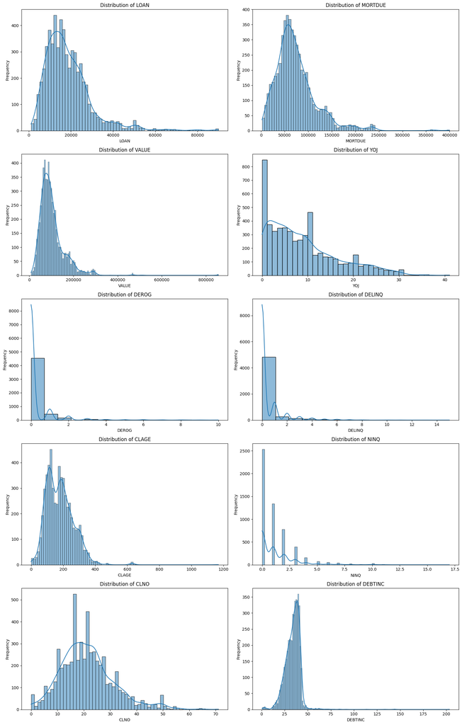

```python
def plot_numeric_histograms(df, numeric_cols, figsize=(16, 5*math.ceil(len(numeric_cols)/2))):
   """
   Create histograms for numeric columns arranged in subplots.
   Uses clean display names for titles and labels.

   Parameters:
   -----------
   df : pandas.DataFrame
       The dataframe containing the numeric columns to plot
   numeric_cols : list
       List of numeric column names to create histograms for
   figsize : tuple, optional
       Figure size as (width, height) in inches, default dynamically calculated based on column count
   """
   # Calculate layout dimensions
   n_plots = len(numeric_cols)
   n_cols = 2  # Show 2 plots per row
   n_rows = math.ceil(n_plots / n_cols)

   # Create the figure and subplots
   fig, axes = plt.subplots(n_rows, n_cols, figsize=figsize)
   axes = axes.flatten() if n_rows * n_cols > 1 else [axes]  # Flatten if multiple plots

   # Create a histogram for each numeric column
   for i, col in enumerate(numeric_cols):
       if i < len(axes):  # Ensure we don't exceed the number of subplots
           # Plot histogram with KDE (Kernel Density Estimation) curve
           sns.histplot(df[col], kde=True, ax=axes[i])
           axes[i].set_title(f'Distribution of {col}')
           axes[i].set_xlabel(col)
           axes[i].set_ylabel('Frequency')

   # Hide any unused subplots if odd number of columns
   for j in range(i+1, len(axes)):
       axes[j].set_visible(False)

   # Adjust spacing between subplots for better readability
   plt.subplots_adjust(wspace=0.3, hspace=0.4)
   plt.tight_layout()
   plt.show()

# Generate histograms for all numeric variables to visualize their distributions
plot_numeric_histograms(df, numeric_cols)
```

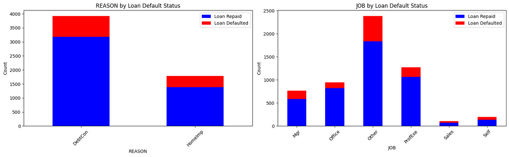

```python
def plot_categorical_bars(df, categorical_cols, figsize=(16, 5*math.ceil(len(categorical_cols)/2))):
   """
   Create stacked bar charts for categorical columns arranged in subplots.
   Each chart shows the distribution of loan defaults vs repayments by category.

   Parameters:
   -----------
   df : pandas.DataFrame
       The dataframe containing the categorical columns to plot
   categorical_cols : list
       List of categorical column names to create bar charts for
   figsize : tuple, optional
       Figure size as (width, height) in inches, default dynamically calculated based on column count
   """
   # Calculate layout dimensions
   n_plots = len(categorical_cols)
   n_cols = 2  # Show 2 plots per row
   n_rows = math.ceil(n_plots / n_cols)

   # Create the figure and subplots
   fig, axes = plt.subplots(n_rows, n_cols, figsize=figsize)
   axes = axes.flatten() if n_rows * n_cols > 1 else [axes]  # Flatten if multiple plots

   # Create a stacked bar chart for each categorical column
   for i, col in enumerate(categorical_cols):
       if i < len(axes):  # Ensure we don't exceed the number of subplots
           # Create cross-tabulation between the categorical variable and the target variable
           crosstab = pd.crosstab(df[col], df['BAD'])

           # Plot stacked bar chart showing distribution of defaults (1) vs non-defaults (0)
           crosstab.plot(kind='bar', stacked=True, ax=axes[i], color=['blue', 'red'])
           axes[i].set_title(f'{col} by Loan Default Status')
           axes[i].set_xlabel(col)
           axes[i].set_ylabel('Count')
           axes[i].tick_params(axis='x', rotation=45)
           axes[i].legend(['Loan Repaid', 'Loan Defaulted'])

   # Hide any unused subplots if odd number of columns
   for j in range(i+1, len(axes)):
       axes[j].set_visible(False)

   # Adjust spacing between subplots for better readability
   plt.subplots_adjust(wspace=0.3, hspace=0.4)
   plt.tight_layout()
   plt.show()

# Generate stacked bar charts for categorical variables to visualize their relationship with loan defaults
plot_categorical_bars(df, categorical_cols)
```

#### Observations:

- **REASON by Loan Default Status**:
  - Debt Consolidation Dominance: Debt consolidation is the more common loan reason, representing approximately twice as many loans as home improvements.
  - Default Rate Differences: Home improvement loans show a visibly higher proportion of defaults (red proportions) compared to debt consolidation loans (22.25% vs. 18.97%).
  - Distribution Pattern: Of the total sample, roughly 65-70% of loans are for debt consolidation, while 30-35% are for home improvements.
  - Risk Indication: The higher default rate for home improvement loans suggests this purpose may carry intrinsically higher risk, despite being less common overall.
- **JOB by Loan Default Status**:
  - Occupational Distribution: "Other" is the most common job category, followed by "ProfExe" (Professional/Executive), with "Sales" being the least represented.
  - Default Rate Variation: Significant differences in default rates (red proportions) across job categories: (1) "Sales" and "Self" (self-employed) show the highest proportion of defaults, (2) "Office" appears to have the lowest proportion of defaults and (3) "Other" and "Mgr" (Manager) have moderate default rates.
  - Professional Advantage: The "ProfExe" category shows a relatively lower default rate compared to most other categories except "Office"
  - High-Risk Segments: The small but notable "Sales" and "Self" categories reveal substantially higher risk profiles, with nearly 30-35% of these loans defaulting
  - Volume vs. Risk Trade-off: While "Other" represents the highest volume of loans, it doesn't correspond to the highest default proportion, suggesting volume alone doesn't predict risk.

These patterns indicate that both loan purpose and occupation type are potentially important predictors for default risk, with clear variations across categories that should be incorporated into the modeling approach. The particularly high default rates for self-employed and sales professionals suggest these segments may warrant special attention during the loan approval process.

### **Bivariate Analysis**

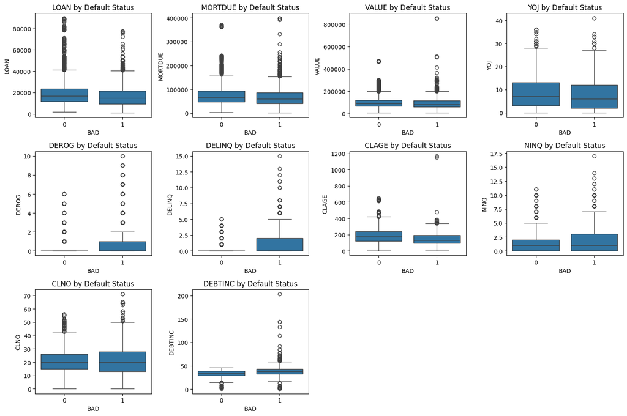

```python
# Create boxplots to compare distributions of numeric variables between default and non-default loans
plt.figure(figsize=(15, 10))  # Set figure size for better readability

# Loop through each numeric column to create individual boxplots
for i, col in enumerate(numeric_cols):
   if col != 'BAD':  # Skip the target variable itself
       plt.subplot(3, 4, i+1)  # Create a grid of subplots (3 rows, 4 columns)

       # Create boxplot showing distribution by default status (0=repaid, 1=defaulted)
       sns.boxplot(x='BAD', y=col, data=df)

       # Add title to each subplot
       plt.title(f'{col} by Default Status')

plt.tight_layout()  # Adjust spacing between subplots to prevent overlap
plt.show()  # Display the figure with all boxplots
```

#### Observations

```python
# Calculate and compare mean values of numeric features between defaulted and non-defaulted loans
# Group data by the target variable 'BAD' and calculate mean for each numeric column
default_stats = df.groupby('BAD')[numeric_cols].mean().T

# Rename columns for clarity (0=Non-Default, 1=Default)
default_stats.columns = ['Non-Default', 'Default']

# Calculate percentage difference between default and non-default means
# Formula: ((Default - Non-Default) / Non-Default) * 100
default_stats['Percent_Difference'] = (default_stats['Default'] - default_stats['Non-Default']) / default_stats['Non-Default'] * 100

# Display the results sorted by percentage difference (highest to lowest)
# This highlights which variables show the greatest relative difference between defaulted and non-defaulted loans
print(default_stats.sort_values('Percent_Difference', ascending=False))
```

```
           Non-Default       Default  Percent_Difference
DEROG         0.134217      0.707804          427.358451
DELINQ        0.245133      1.229185          401.437034
NINQ          1.032749      1.782765           72.623230
DEBTINC      33.253129     39.387645           18.447937
CLNO         21.317036     21.211268           -0.496169
VALUE    102595.921018  98172.846227           -4.311160
MORTDUE   74829.249055  69460.452973           -7.174729
LOAN      19028.107315  16922.119428          -11.067774
YOJ           9.154941      8.027802          -12.311805
CLAGE       187.002355    150.190183          -19.685405
```

#### Observations:

This table reveals striking differences in feature values between defaulting and non-defaulting loans:

- Strongest Default Indicators: DEROG and DELINQ show the most dramatic differences with 427% and 401% higher values in defaulting loans. This means defaulters have approximately 4x more derogatory reports and delinquent credit lines than non-defaulters.
- Secondary Risk Factors: NINQ (recent credit inquiries) shows a 73% increase in defaulting loans, while DEBTINC (debt-to-income ratio) is 18% higher, confirming that debt burden significantly influences default risk.
- Protective Factors: CLAGE (credit age) is 20% lower for defaulters, suggesting established credit history provides significant protection. YOJ (years at job) is 12% lower for defaulters, indicating employment stability reduces default risk.
- Counterintuitive Findings: Defaulting loans have slightly lower LOAN amounts (-11%), MORTDUE (-7%), and VALUE (-4%), contradicting the intuition that larger loans carry higher default risk. This may indicate stricter underwriting for larger loans.

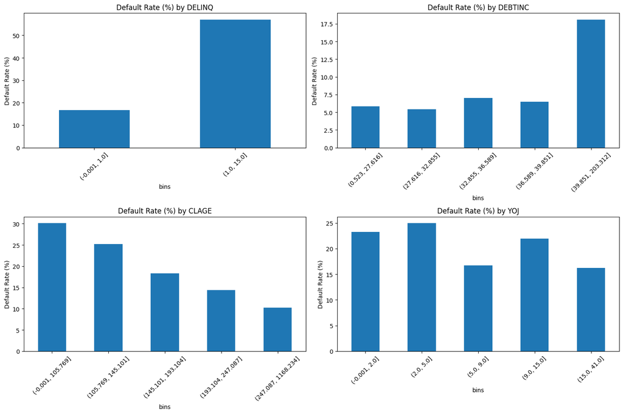

```python
# Analyze default rates across different value ranges for key variables
key_vars = ['DELINQ', 'DEBTINC', 'CLAGE', 'YOJ']  # Selected key variables identified in EDA

plt.figure(figsize=(15, 10))
for i, var in enumerate(key_vars):
    plt.subplot(2, 2, i+1)  # Create a 2x2 grid of subplots

    # Create bins (quintiles) for each variable, dropping duplicates if needed
    df['bins'] = pd.qcut(df[var].dropna(), 5, duplicates='drop')

    # Calculate default rate (percentage) for each bin - with the fix
    default_by_bin = df.groupby('bins', observed=True)['BAD'].mean() * 100

    # Plot the default rates as a bar chart
    default_by_bin.plot(kind='bar')

    # Add labels and title
    plt.title(f'Default Rate (%) by {var}')
    plt.ylabel('Default Rate (%)')
    plt.xticks(rotation=45)  # Rotate x-axis labels for readability

    # Remove the temporary 'bins' column to avoid affecting subsequent analysis
    df.drop('bins', axis=1, inplace=True)

plt.tight_layout()  # Adjust spacing between subplots
plt.show()  # Display the plots
```

#### Observations:

These bar charts reveal critical threshold effects and non-linear relationships:

- DELINQ (Delinquencies): Shows a dramatic step function with default rates jumping from ~17% (0-1 delinquencies) to ~55% (1+ delinquencies). This confirms delinquency as perhaps the single strongest predictor, with a clear threshold effect.
- DEBTINC (Debt-to-Income): Reveals a threshold effect at the highest bin, where default rates suddenly triple to nearly 18% when debt-to-income exceeds 39%. The first four categories show relatively stable default rates (5-7%), suggesting a nonlinear relationship.
- CLAGE (Credit Age): Shows a clear monotonic decreasing relationship where default risk steadily declines as credit history lengthens. The relationship appears nearly linear, with each increasing bin of credit age associated with approximately 5% reduction in default rate.
- YOJ (Years on Job): Displays a non-monotonic pattern with highest default rates among very new employees (0-2 years) and those with 2-5 years tenure. A notable dip occurs in the 5-9 year range, suggesting mid-career stability may be protective.

#### Key Insights from Bivariate Analysis

- Critical Risk Indicators: Delinquent credit lines and derogatory reports are by far the strongest predictors, with effects several times larger than other variables.
- Threshold Effects: Several variables show clear threshold effects where risk dramatically changes at specific values (particularly DELINQ and DEBTINC).
- Nonlinear Relationships: YOJ shows a complex relationship with default risk that wouldn't be captured by simple linear models.
- Counterintuitive Size Effect: Smaller loans show higher default rates, suggesting different underwriting standards or borrower profiles across loan size segments.
- Combined Risk Assessment: The collective evidence suggests a strong model would emphasize credit history quality (DELINQ, DEROG), debt burden (DEBTINC), credit maturity (CLAGE), and employment stability (YOJ).

These findings provide compelling guidance for model development, suggesting that threshold-based approaches or models capable of capturing non-linear relationships would be most effective for predicting loan defaults.

### **Multivariate Analysis**

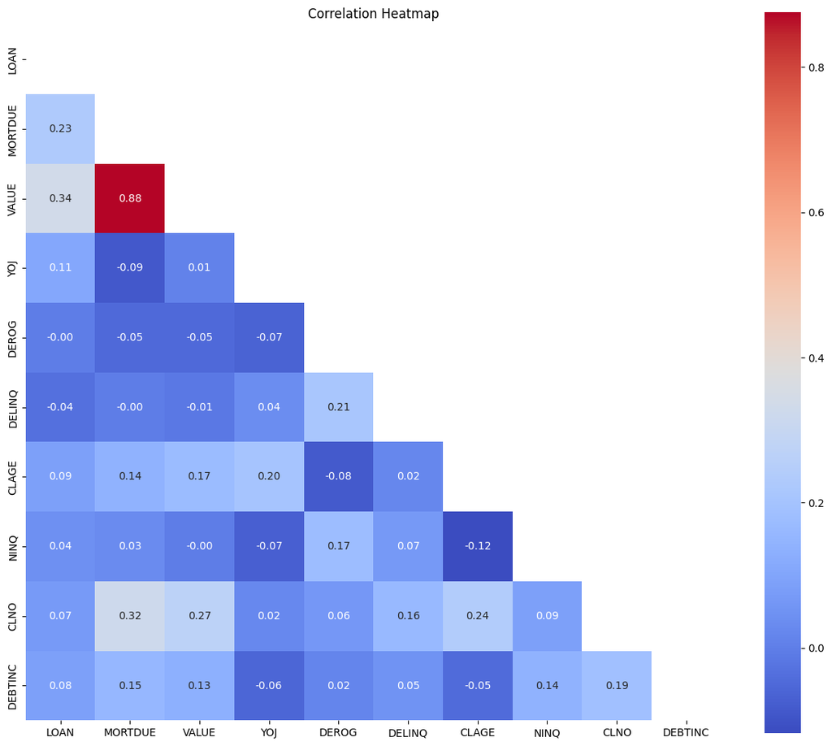

```python
# Generate a correlation heatmap to visualize relationships between numeric variables
plt.figure(figsize=(12, 10))  # Set figure size for better readability

# Calculate the correlation matrix for numeric variables
corr = df[numeric_cols].corr()

# Create a mask for the upper triangle to avoid redundant display
# triu = upper triangle, ones_like creates a matrix of 1s with same shape as corr
mask = np.triu(np.ones_like(corr, dtype=bool))

# Generate the heatmap with annotations
sns.heatmap(
   corr,                  # Correlation matrix
   mask=mask,             # Apply mask to show only lower triangle
   annot=True,            # Show correlation values on cells
   fmt=".2f",             # Format for correlation values (2 decimal places)
   cmap="coolwarm",       # Color scheme (blue=negative, red=positive)
   square=True            # Ensure cells are square-shaped
)

plt.title("Correlation Heatmap")  # Add title
plt.tight_layout()               # Adjust spacing for better display
plt.show()                       # Display the heatmap
```

#### Observations:

This correlation matrix reveals key relationships between predictor variables:

- Strongest Correlation: MORTDUE and VALUE show the highest correlation (0.88), indicating that property value and mortgage amount are closely linked—this multicollinearity will need consideration in modeling. The strong relationship suggests these variables provide redundant information, and feature engineering (such as loan-to-value ratio) might be more effective than including both raw variables.
- Moderate Property-Loan Relationships: VALUE and LOAN show a notable correlation (0.34), suggesting that larger loans are moderately associated with higher-value properties. This makes logical sense but isn't strong enough to indicate redundancy, implying that loan amounts are determined by factors beyond just property value.
- Credit Line Relationships: CLNO (number of credit lines) shows moderate correlations with MORTDUE (0.32) and VALUE (0.27), suggesting borrowers with more expensive properties tend to have more credit lines. This pattern likely reflects that higher-income borrowers qualify for both larger mortgages and more credit opportunities.
- Independence of Risk Factors: Key default predictors (DEROG, DELINQ, NINQ) show very low correlations with each other (mostly below 0.21), suggesting they capture distinct aspects of credit risk and may provide complementary predictive power. The modest positive correlation (0.21) between DEROG and DELINQ makes intuitive sense as both measure different aspects of credit problems.
- Weak Employment-Credit Relationships: YOJ shows minimal correlation with credit variables, suggesting employment stability and credit behavior represent independent risk dimensions. Surprisingly, YOJ has slightly negative correlations with MORTDUE (-0.09) and DEROG (-0.07), which might indicate that recently employed borrowers are pursuing larger loans despite potentially weaker credit.
- Credit Age Factors: CLAGE shows modest positive correlations with property metrics (VALUE: 0.17, MORTDUE: 0.14) and YOJ (0.20), indicating more established borrowers tend to have both longer credit and employment histories. The negative correlation (-0.12) between CLAGE and NINQ suggests borrowers with established credit histories make fewer recent credit inquiries.
- Debt-to-Income Insights: DEBTINC shows weak positive correlations with LOAN (0.08), MORTDUE (0.15), and NINQ (0.14), suggesting these factors marginally contribute to higher debt burdens. The lack of stronger correlations with debt metrics may indicate that DEBTINC captures financial strain dimensions not reflected in other variables.
- Overall Low Correlations: Most variables show weak correlations with each other (blue squares), indicating limited multicollinearity concerns for most variable pairs and suggesting each variable contributes unique information to the default prediction model. This pattern supports including most variables in the model without significant information redundancy.

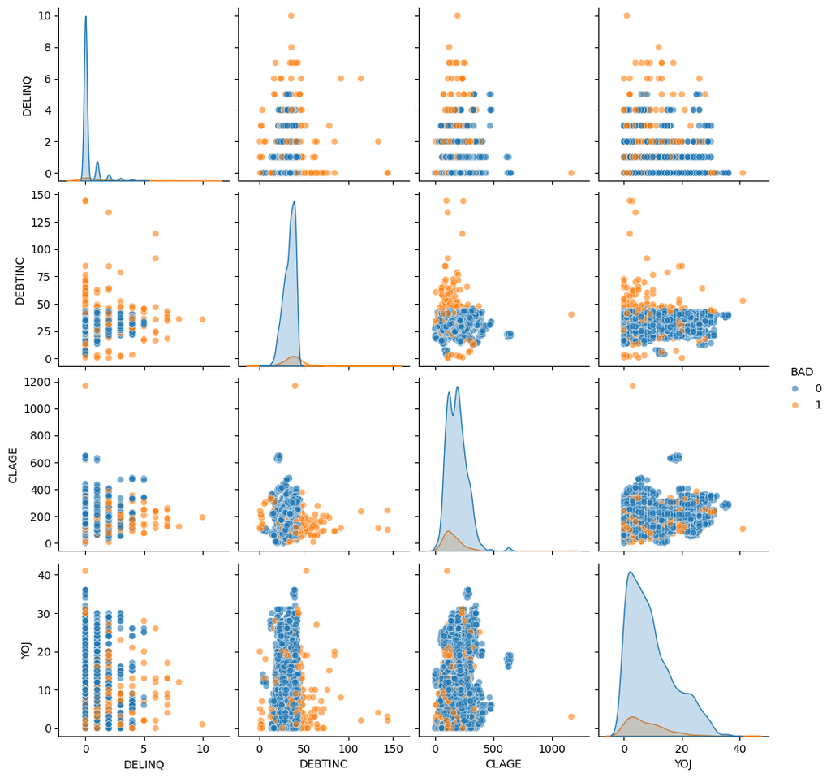

```python
# Select key variables for visualization
key_variables = ['DELINQ', 'DEBTINC', 'CLAGE', 'YOJ', 'BAD']

# Create a pairplot to visualize relationships between key variables
# - dropna() removes rows with missing values to ensure clean visualization
# - hue='BAD' colors points based on the target variable (loan default status)
# - diag_kind='kde' uses Kernel Density Estimation for diagonal plots
# - plot_kws={'alpha': 0.6} adds transparency to points for better visibility
sns.pairplot(df[key_variables].dropna(), hue='BAD', diag_kind='kde', plot_kws={'alpha': 0.6})

# Display the pairplot
plt.show()
```

#### Observations:

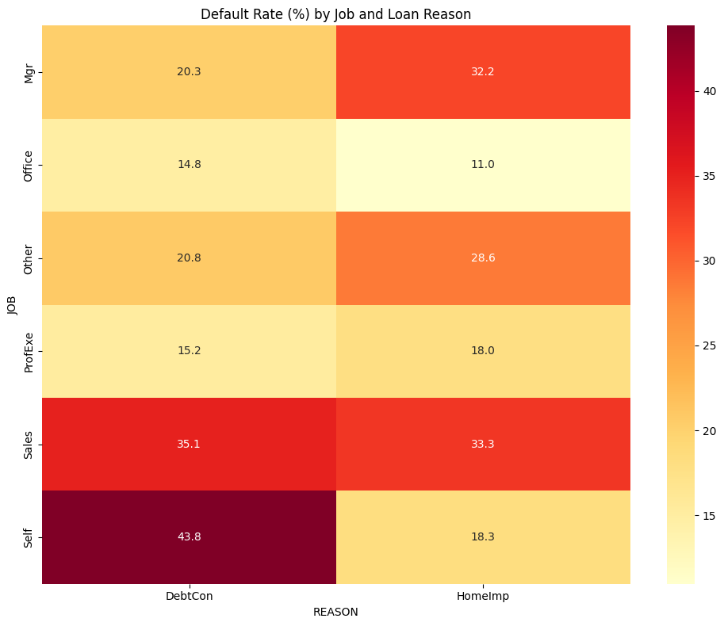

```python
# Analyze default rates by cross-tabulating job categories and loan reasons
# Create a cross-tabulation to calculate mean default rates
# pd.crosstab combines categorical variables and computes default percentages
cross_tab = pd.crosstab(
    [df['JOB']],        # Rows: Job categories
    [df['REASON']],     # Columns: Loan reasons
    values=df['BAD'],   # Use 'BAD' column to calculate mean (default indicator)
    aggfunc='mean'      # Compute mean to get default rate
).fillna(0) * 100       # Convert to percentage, replace NaNs with 0

# Visualize default rates using a heatmap
plt.figure(figsize=(10, 8))  # Set figure size for better readability

# Create heatmap with detailed annotations
sns.heatmap(
    cross_tab,          # Default rate percentages
    annot=True,         # Show numerical values in each cell
    fmt='.1f',          # Format to show one decimal place
    cmap='YlOrRd'       # Color map: Yellow to Orange to Red (intensity indicates default rate)
)

# Add title and adjust layout
plt.title('Default Rate (%) by Job and Loan Reason')
plt.tight_layout()  # Automatically adjust subplot parameters for optimal layout
plt.show()  # Display the heatmap
```

#### Observations:

This heatmap reveals critical interactions between job categories and loan purposes:

- Self-employed Debt Consolidation Risk: Self-employed borrowers seeking debt consolidation show the highest default rate (43.8%) of any combination—more than twice the risk of self-employed borrowers seeking home improvement loans (18.3%). This dramatic difference suggests self-employed individuals may take on unsustainable debt consolidation loans, possibly due to business cash flow challenges or irregular income patterns.
- Sales Professionals: Sales professionals show consistently high default rates regardless of loan purpose (35.1% for debt consolidation, 33.3% for home improvement), suggesting this occupation category carries inherent financial instability. This may reflect commission-based income volatility that makes maintaining consistent loan payments difficult.
- Differential Impact of Loan Purpose: Debt consolidation loans show higher default rates for office workers (14.8% vs 11.0%), self-employed (43.8% vs 18.3%), and sales professionals (35.1% vs 33.3%). Conversely, home improvement loans show higher risk for managers (32.2% vs 20.3%), "other" occupations (28.6% vs 20.8%), and professionals (18.0% vs 15.2%). This suggests loan purpose risk varies significantly by occupation.
- Lowest Risk Segment: Office workers seeking home improvement loans show the lowest default rate (11.0%) of any combination, suggesting strong financial stability in this group. This may reflect the combination of steady employment with productive home investment.
- Managerial Contrast: Managers show dramatically different risk profiles based on loan purpose—20.3% default for debt consolidation versus 32.2% for home improvements, a 12% difference that suggests careful evaluation of purpose for this group. This unexpected pattern might indicate that managers overextend on home improvements relative to their financial capacity.
- Overall Risk by Job Category: Averaging across loan purposes, self-employed (31.1%) and sales professionals (34.2%) represent the highest-risk occupations, while office workers (12.9%) and professionals (16.6%) show the lowest default rates. This aligns with expectations about income stability across these professions.
- Overall Risk by Loan Purpose: For most occupational categories, debt consolidation loans (25.0% average default) appear similar in overall risk to home improvement loans (23.6% average default), suggesting that borrower characteristics may matter more than loan purpose in determining default probability.

#### Key Insights from Multivariate Analysis

- **Interaction Patterns**: The visualizations reveal important variable relationships worth considering in modeling:
  - DELINQ × DEBTINC (high values in both dramatically increase default risk)
  - JOB × REASON (particularly the 25.5% difference for self-employed borrowers between loan purposes)
  - DELINQ × CLAGE (newer credit histories combined with any delinquencies show elevated default rates)
  - DEBTINC × Credit Variables (high debt ratios amplify the risk of negative credit indicators)
- **Segmentation Potential**: The heatmap suggests potential value in segmented models by:
  - Job category (especially separate treatment for self-employed and sales professionals who show default rates >30%)
  - Loan purpose (different risk factors for different purposes, with debt consolidation particularly risky for self-employed borrowers)
  - Customer stability profile (combining YOJ and CLAGE to identify established vs. new borrowers)
- **Multicollinearity Considerations**: The correlation matrix shows:
  - Strong MORTDUE-VALUE relationship (0.88) requiring attention, possibly by creating a loan-to-value ratio
  - Moderate VALUE-LOAN correlation (0.34) suggesting some relationship but not redundancy
  - Notable CLNO-MORTDUE correlation (0.32) indicating relationship between credit lines and mortgage size
  - Otherwise limited multicollinearity, supporting inclusion of most variables
- **Feature Engineering Opportunities**: The visualizations suggest valuable derived features:
  - Categorical flags for delinquency status (0 vs 1+) given the strong signal at this threshold
  - Risk tiers for DEBTINC with emphasis on regulatory thresholds (43%) and extreme values (>60%)
  - Employment stability indicators combining YOJ with JOB categories
  - Credit maturity metric combining CLAGE with CLNO to measure credit establishment

These multivariate patterns provide critical guidance for model selection and feature engineering, suggesting that models capable of capturing non-linear relationships and interactions (like gradient boosting or random forests) would be particularly effective for this loan default prediction problem.

## Treating Outliers

The following analysis was used to determine treatment of outliers within the dataset:

1. **Credit Risk Indicators (DEROG, DELINQ, NINQ)**: High values represent legitimate high-risk borrowers and therefore should not be removed from the dataset. The extreme values (e.g., DELINQ > 5) are rare but highly predictive of default.
2. **CLAGE (Credit Age)**: The maximum value of 1,168 months(~97 years) is implausible and likely an error. Therefore it was decided to cap the maximum value at a reasonable threshold (e.g., 720 months/60 years), a higher cap was chosen as very long-term credit histories could exist. The large quanitity of zero values could have been misinterpreted as error or even missing value but since CLAGE is in unit months, they likely represent genuine new credit accounts less than one month old.
3. **DEBTINC (Debt-to-Income)**: High values exceed typical lending standards, however they can occur in rare instances. The maximum of 203% is unusual but possible for borrowers experiencing income fluctuations.
4. **Property Values and Loans (VALUE, MORTDUE, LOAN)**: All observed values are plausible in real estate markets. The maximum property value of USD855,909 is high but entirely realistic for luxury properties.
   - Log transformation will normalize their distributions while preserving their relative relationships
5. **YOJ (Years on Job)**: All values should be kept as they are plausible employment durations. Zero values represent newly employed individuals, an important risk segment.
6. **CLNO (Number of Credit Lines)**: Retain all values, while 71 credit lines is high, it's not impossible for someone with multiple trade lines, retail accounts, and historical accounts. Very high values may represent legitimate complex credit profiles rather than errors.

Note: all outlier treatment should be vetted with stakeholders and industry professionals to ensure that all plausible values are left intact and that the above proposed outlier treatment makes sense within the given context.

```python
def treat_outliers(df):
    """
    Perform outlier treatment on the input DataFrame.

    Parameters:
    -----------
    df : pandas.DataFrame
        Input DataFrame containing the original features

    Returns:
    --------
    pandas.DataFrame
        DataFrame with outlier treatment applied
    """
    # Create a deep copy of the input DataFrame to avoid modifying the original data
    df_treated = df.copy()

    # Clip CLAGE (Credit Line Age) to a maximum of 720 months (60 years)
    df_treated['CLAGE'] = df_treated['CLAGE'].clip(upper=720)

    # Apply log transformation to selected numerical features
    # log1p is used to handle zero values and reduce the impact of extreme outliers
    # Transforms: LOAN, MORTDUE, and VALUE
    for col in ['LOAN', 'MORTDUE', 'VALUE']:
        df_treated[f'{col}_LOG'] = np.log1p(df_treated[col])

    return df_treated

# Apply outlier treatment to the DataFrame
df_treated = treat_outliers(df)

# Display the first few rows of the treated DataFrame to verify transformations
df_treated.head()
```

|  | BAD | LOAN | MORTDUE | VALUE | REASON | JOB | YOJ | DEROG | DELINQ | CLAGE | NINQ | CLNO | DEBTINC | LOAN_LOG | MORTDUE_LOG | VALUE_LOG |
| --- | --- | --- | --- | --- | --- | --- | --- | --- | --- | --- | --- | --- | --- | --- | --- | --- |
| 0 | 1 | 1100 | 25860.0 | 39025.0 | HomeImp | Other | 10.5 | 0.0 | 0.0 | 94.366667 | 1.0 | 9.0 | NaN | 7.003974 | 10.160491 | 10.571983 |
| 1 | 1 | 1300 | 70053.0 | 68400.0 | HomeImp | Other | 7.0 | 0.0 | 2.0 | 121.833333 | 0.0 | 14.0 | NaN | 7.170888 | 11.157022 | 11.133143 |
| 2 | 1 | 1500 | 13500.0 | 16700.0 | HomeImp | Other | 4.0 | 0.0 | 0.0 | 149.466667 | 1.0 | 10.0 | NaN | 7.313887 | 9.510519 | 9.723224 |
| 3 | 1 | 1500 | NaN | NaN | NaN | NaN | NaN | NaN | NaN | NaN | NaN | NaN | NaN | 7.313887 | NaN | NaN |
| 4 | 0 | 1700 | 97800.0 | 112000.0 | HomeImp | Office | 3.0 | 0.0 | 0.0 | 93.333333 | 0.0 | 14.0 | NaN | 7.438972 | 11.490690 | 11.626263 |

## Treating Missing Values

The following analysis was used to determine treatment of Missing values within the dataset:

1. **BAD and LOAN**: No missing values, no value treatment or imputation needed.
2. **MORTDUE**: 8.7% missing values, imputed using mortgage-to-value ratio where VALUE exists and remaining missing values substituted with overall median
3. **VALUE**: 1.9% missing values, imputed using mortgage-to-value ratio where MORTDUE exists and remaining missing values substituted with overall median
4. **REASON**: 4.2% missing values, create 'unknown' category for missing value treatment.
5. **JOB**: 4.7% missing values, create 'unknown' category for missing value treatment.
6. **YOJ**: 8.6% missing values, median imputation by job category (i.e. JOB will indicate the nature of employment and therefore the likely number of years employed - taking the median of the YOJ for each JOB category can give a rough idea and help impute the missing YOJ data).
7. **DEROG**: 11.9% missing values, zero imputation for missing value treatment (i.e. it is possible for a person to have no derogatory reports and therefore replacing with zero makes sense).
8. **DELINQ**: 9.7% missing values, zero imputation for missing value treatment (i.e. it is possible for a person to have no delinquencies and therefore replacing with zero makes sense).
9. **CLAGE**: 5.2% missing values, imputed using CLNO bins as primary predictor where exists (grouped by number of credit lines) and remaining missing values substituted with overall median
10. **NINQ**: 8.6% missing values, zero imputation for missing value treatment (i.e. it is possible for a person to have no recent inquiries and therefore replacing with zero makes sense).
11. **CLNO**: 3.7% missing values, imputed using MORTDUE bins as primary predictor where exists (grouped by mortgage amount) and remaining missing values substituted with overall median.
12. **DEBTINC**: 21.3% missing values, model based imputation using other financial variables.

Note: all missing value treatment should be vetted with stakeholders and industry professionals to ensure that all imputed values are plausible and that the above proposed missing value treatment makes sense within the given context.

```python
def treat_missing_values(df):
    """
    Comprehensive missing value imputation strategy for loan dataset

    Imputation methods:
    1. MORTDUE and VALUE: Leverage relationship between mortgage due and property value
    2. REASON and JOB: Replace missing values with 'Unknown'
    3. YOJ (Years on Job): Median imputation by job category
    4. DEROG, DELINQ, NINQ: Zero imputation
    5. CLNO: Targeted imputation based on mortgage amount bins
    6. CLAGE: Targeted imputation based on credit line number bins
    7. DEBTINC: Advanced model-based imputation using Random Forest

    Returns:
    --------
    pandas.DataFrame
        DataFrame with missing values comprehensively treated
    """
    # Create a deep copy to prevent modifying the original DataFrame
    df_treated = df.copy()

    # 2-3. MORTDUE and VALUE - Handle missing values using their inherent relationship
    # Calculate median ratio between mortgage due and property value
    mtv_ratio = df.loc[df['MORTDUE'].notna() & df['VALUE'].notna(), 'MORTDUE'].median() / \
            df.loc[df['MORTDUE'].notna() & df['VALUE'].notna(), 'VALUE'].median()

    # Impute MORTDUE where VALUE is available
    # Uses the calculated ratio to estimate missing mortgage due amount
    mask = df_treated['MORTDUE'].isna() & df_treated['VALUE'].notna()
    df_treated.loc[mask, 'MORTDUE'] = df_treated.loc[mask, 'VALUE'] * mtv_ratio

    # Impute VALUE where MORTDUE is available
    # Reverse of previous imputation using inverse of the ratio
    mask = df_treated['VALUE'].isna() & df_treated['MORTDUE'].notna()
    df_treated.loc[mask, 'VALUE'] = df_treated.loc[mask, 'MORTDUE'] / mtv_ratio

    # Fill remaining missing MORTDUE and VALUE with their respective medians
    df_treated['MORTDUE'] = df_treated['MORTDUE'].fillna(df_treated['MORTDUE'].median())
    df_treated['VALUE'] = df_treated['VALUE'].fillna(df_treated['VALUE'].median())

    # 4-5. REASON and JOB - Replace missing categorical values with 'Unknown'
    df_treated['REASON'] = df_treated['REASON'].fillna('Unknown')
    df_treated['JOB'] = df_treated['JOB'].fillna('Unknown')

    # 6. YOJ (Years on Job) - Median imputation by job category
    # This approach preserves job-specific employment patterns
    df_treated['YOJ'] = df_treated.groupby('JOB', observed=True)['YOJ'].transform(
        lambda x: x.fillna(x.median()))
    # Fallback to overall median if any missing values remain
    df_treated['YOJ'] = df_treated['YOJ'].fillna(df_treated['YOJ'].median())

    # 7, 8 & 10. DEROG, DELINQ, NINQ - Zero imputation
    # Assumes missing values indicate no negative events
    for col in ['DEROG', 'DELINQ', 'NINQ']:
        df_treated[col] = df_treated[col].fillna(0)

    # 11. CLNO (Credit Line Number) - Targeted imputation based on mortgage amount
    if df_treated['CLNO'].isna().sum() > 0:
        # Create mortgage amount bins for more precise imputation
        df_treated['MORTDUE_BIN'] = pd.cut(df_treated['MORTDUE'],
                                        bins=[0, 50000, 100000, 150000, 500000],
                                        labels=['0-50k', '50k-100k', '100k-150k', '150k+'])

        # Impute CLNO using median within mortgage amount groups
        df_treated['CLNO'] = df_treated.groupby('MORTDUE_BIN', observed=True)['CLNO'].transform(
            lambda x: x.fillna(x.median()))
        df_treated.drop('MORTDUE_BIN', axis=1, inplace=True)

        # Fallback to overall median if any missing values persist
        df_treated['CLNO'] = df_treated['CLNO'].fillna(df_treated['CLNO'].median())

    # 12. CLAGE (Credit Line Age) - Targeted imputation based on credit line number
    if df_treated['CLAGE'].isna().sum() > 0:
        # Create credit line number bins for precise imputation
        df_treated['CLNO_BIN'] = pd.cut(df_treated['CLNO'],
                                       bins=[0, 10, 20, 30, 100],
                                       labels=['0-10', '10-20', '20-30', '30+'])

        # Impute CLAGE using median within credit line groups
        df_treated['CLAGE'] = df_treated.groupby('CLNO_BIN', observed=True)['CLAGE'].transform(
            lambda x: x.fillna(x.median()))
        df_treated.drop('CLNO_BIN', axis=1, inplace=True)

        # Fallback to overall median if any missing values remain
        df_treated['CLAGE'] = df_treated['CLAGE'].fillna(df_treated['CLAGE'].median())

    # 13. DEBTINC (Debt to Income Ratio) - Advanced model-based imputation
    if df_treated['DEBTINC'].isna().sum() > 0:
        # Separate DataFrame into rows with and without missing DEBTINC
        df_missing = df_treated[df_treated['DEBTINC'].isna()].copy()
        df_complete = df_treated[df_treated['DEBTINC'].notna()].copy()

        # Select predictive features for DEBTINC
        predictors = ['LOAN', 'MORTDUE', 'VALUE', 'CLNO', 'CLAGE']

        # Use Random Forest Regressor for sophisticated imputation
        from sklearn.ensemble import RandomForestRegressor
        model = RandomForestRegressor(n_estimators=100, random_state=42)
        model.fit(df_complete[predictors], df_complete['DEBTINC'])

        # Predict missing DEBTINC values
        df_missing['DEBTINC'] = model.predict(df_missing[predictors])

        # Recombine and sort to maintain original index
        df_treated = pd.concat([df_complete, df_missing]).sort_index()

    # Handle log-transformed columns to ensure no missing values
    for col in df_treated.columns:
        if col.endswith('_LOG') and df_treated[col].isna().sum() > 0:
            original_col = col.replace('_LOG', '')
            if original_col in df_treated.columns:
                # Reapply log1p transformation for any missing log columns
                df_treated[col] = np.log1p(df_treated[original_col])

    return df_treated

# Apply comprehensive missing value treatment
df_treated = treat_missing_values(df_treated)

# Display first few rows to verify transformations
df_treated.head()
```

[output not shown]

```python
# Sanity check: ensure that the treat_missing_values function results in a dataset with no missing values
print("\nMissing Values:")
df_treated.isnull().sum()
```

```
Missing Values:
```

|  | 0 |
| --- | --- |
| BAD | 0 |
| LOAN | 0 |
| MORTDUE | 0 |
| VALUE | 0 |
| REASON | 0 |
| JOB | 0 |
| YOJ | 0 |
| DEROG | 0 |
| DELINQ | 0 |
| CLAGE | 0 |
| NINQ | 0 |
| CLNO | 0 |
| DEBTINC | 0 |
| LOAN_LOG | 0 |
| MORTDUE_LOG | 0 |
| VALUE_LOG | 0 |

**dtype:** int64

#### Observations:

- **Outlier Handling**: The approach correctly preserves legitimate risk signals in credit indicators (DEROG, DELINQ, NINQ) while addressing problematic extremes in CLAGE (capping at 720 months). The log transformation of monetary values (LOAN, MORTDUE, VALUE) effectively normalizes their distributions without losing information — an appropriate choice for financial data.
- **Missing Value Treatment**: The imputation strategy shows domain understanding by using specialized approaches for different variables:
  - Creating "Unknown" categories for REASON and JOB preserves the potential signal in missingness
  - Using zero imputation for DEROG, DELINQ, and NINQ aligns with business logic
  - Employing group-based imputation for YOJ (by job category) and CLNO (by mortgage amount) leverages data relationships
  - Using model-based imputation for the heavily missing DEBTINC (21.3%) provides plausible values based on other financial indicators

## **Important Insights from EDA**

What are the the most important observations and insights from the data based on the EDA performed?

Loan default prediction is driven by credit history quality, financial stability, and applicant characteristics that interact in complex ways. The strongest predictors are delinquent credit lines (DELINQ) and derogatory reports (DEROG), with 400%+ higher values in defaulting loans. Clear threshold effects exist for several variables, particularly the powerful interaction between occupation and loan purpose. The data suggests a multi-faceted approach combining binary exclusion rules for severe credit issues, graduated scoring for financial metrics, and targeted policies for high-risk combinations of characteristics.

## **Model Building**

- Data preparation
- Partition the data into train and test set
- Build the model
- Fit on the train data
- Tune the model
- Test the model on test set

```python
# Encode other categorical variables using Label Encoding
le_dict = {}
for col in categorical_cols:
    le = LabelEncoder()
    df_treated[col] = le.fit_transform(df_treated[col])
    le_dict[col] = le
```

```python
# Separating features and target variable
X = df_treated.drop(['BAD'], axis=1)
y = df_treated['BAD']
```

```python
# Split the data into training and testing sets
X_train, X_test, y_train, y_test = train_test_split(X, y, test_size=0.3,
                                                   random_state=42, stratify=y)

print("\nTraining set shape:", X_train.shape)
print("Testing set shape:", X_test.shape)
```

```
Training set shape: (4172, 15)
Testing set shape: (1788, 15)
```

```python
# Scale features using StandardScaler
scaler = StandardScaler()
X_train_scaled = scaler.fit_transform(X_train)
X_test_scaled = scaler.transform(X_test)
```

```python
def metrics_score(actual, predicted):
    """
    Evaluate model performance through comprehensive metrics visualization.

    Parameters:
    -----------
    actual : array-like
        True labels/ground truth values
    predicted : array-like
        Model's predicted labels

    Outputs:
    --------
    Classification Report:
        - Precision
        - Recall
        - F1-Score
        - Support for each class

    Confusion Matrix Visualization:
        - Heatmap showing prediction accuracy
        - Annotated with prediction counts
    """
    print(classification_report(actual, predicted))

    cm = confusion_matrix(actual, predicted)
    plt.figure(figsize=(8, 5))
    sns.heatmap(cm, annot=True, fmt='.2f', xticklabels=['Not Converted', 'Converted'],
                yticklabels=['Not Converted', 'Converted'])
    plt.ylabel('Actual')
    plt.xlabel('Predicted')
    plt.title('Confusion Matrix')
    plt.show()
```

```python
def model_performance_classification(model, predictors, target):
    """
    Evaluate classification model performance using key metrics.

    Parameters:
    -----------
    model : object
        Trained machine learning classification model
    predictors : array-like
        Input features used for prediction
    target : array-like
        True target labels

    Returns:
    --------
    pandas.DataFrame
        Performance metrics including:
        - Precision (macro average)
        - Recall (macro average)
        - Accuracy
    """
    # Predicting using the independent variables
    pred = model.predict(predictors)

    recall = recall_score(target, pred, average='macro')  # To compute recall
    precision = precision_score(target, pred, average='macro')  # To compute precision
    acc = accuracy_score(target, pred)  # To compute accuracy score

    # Creating a dataframe of metrics
    df_perf = pd.DataFrame(
        {
            "Precision": precision,
            "Recall": recall,
            "Accuracy": acc,
        },
        index=[0],
    )

    return df_perf
```

### **Logistic Regression**

```python
# Initialize and train Logistic Regression with balanced class weights
log_reg = LogisticRegression(random_state=42, max_iter=2000, class_weight='balanced')
log_reg.fit(X_train_scaled, y_train)
```

```
LogisticRegression(class_weight='balanced', max_iter=2000, random_state=42)
```

```python
# Make predictions
y_pred = log_reg.predict(X_test_scaled)
y_pred_proba = log_reg.predict_proba(X_test_scaled)[:, 1]  # Probability of default
```

```
Performance on Training Set:
              precision    recall  f1-score   support

           0       0.91      0.79      0.85      3340
           1       0.45      0.68      0.54       832

    accuracy                           0.77      4172
   macro avg       0.68      0.73      0.69      4172
weighted avg       0.82      0.77      0.79      4172
```

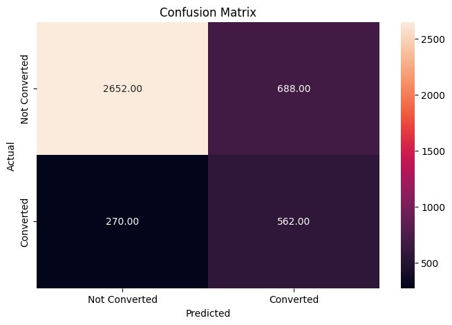

```
Performance on Test Set:
              precision    recall  f1-score   support

           0       0.90      0.81      0.85      1431
           1       0.46      0.65      0.54       357

    accuracy                           0.78      1788
   macro avg       0.68      0.73      0.69      1788
weighted avg       0.81      0.78      0.79      1788
```

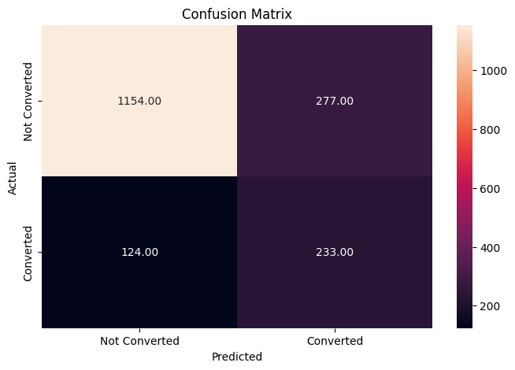

```
ROC AUC Score: 0.8026316047033767
```

```python
# Evaluate model on training data
print("\nPerformance on Training Set:")
y_train_pred = log_reg.predict(X_train_scaled)
metrics_score(y_train, y_train_pred)

# Evaluate model on test data
print("\nPerformance on Test Set:")
y_test_pred = log_reg.predict(X_test_scaled)
metrics_score(y_test, y_test_pred)
print("\nROC AUC Score:", roc_auc_score(y_test, y_pred_proba))
```

```python
# Model performance metrics
log_reg_test_perf = model_performance_classification(log_reg, X_test_scaled, y_test)
print("\nModel Performance Metrics:")
log_reg_test_perf
```

```
Model Performance Metrics:
```

|  | Precision | Recall | Accuracy |
| --- | --- | --- | --- |
| 0 | 0.679918 | 0.729545 | 0.775727 |

```
Model Comparison Results:
             Model  Accuracy  Precision  Recall  F1-Score
0       LR-default    0.7757     0.8139  0.7757    0.7892
1     LR-more-iter    0.7757     0.8139  0.7757    0.7892
2     LR-liblinear    0.7757     0.8139  0.7757    0.7892
3  LR-stronger-reg    0.7752     0.8131  0.7752    0.7886
```

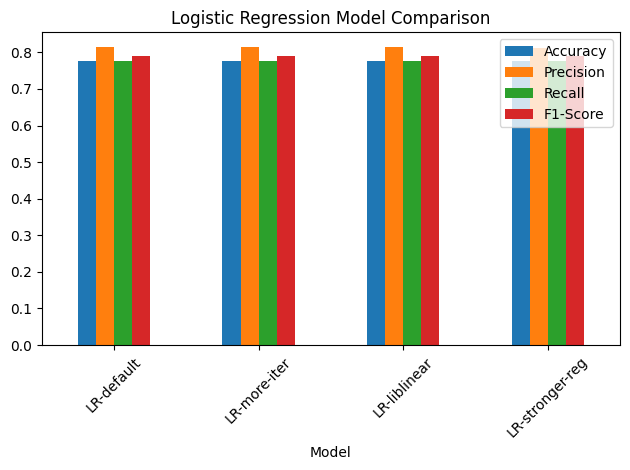

```python
# List of models to compare
models = [
    ('LR-default', LogisticRegression(random_state=42, max_iter=1000, class_weight='balanced')),
    ('LR-more-iter', LogisticRegression(random_state=42, max_iter=2000, class_weight='balanced')),
    ('LR-liblinear', LogisticRegression(random_state=42, solver='liblinear', class_weight='balanced')),
    ('LR-stronger-reg', LogisticRegression(random_state=42, C=0.1, max_iter=1000, class_weight='balanced'))
]

# Create a DataFrame to store results
results_columns = ['Model', 'Accuracy', 'Precision', 'Recall', 'F1-Score']
results_data = []

# Train and evaluate each model
for name, model in models:
    # Fit the model
    model.fit(X_train_scaled, y_train)

    # Predict on test set
    y_pred = model.predict(X_test_scaled)

    # Calculate metrics
    accuracy = accuracy_score(y_test, y_pred)
    precision = precision_score(y_test, y_pred, average='weighted')
    recall = recall_score(y_test, y_pred, average='weighted')
    f1 = f1_score(y_test, y_pred, average='weighted')

    # Store results
    results_data.append([
        name,
        round(accuracy, 4),
        round(precision, 4),
        round(recall, 4),
        round(f1, 4)
    ])

# Create and display results DataFrame
results_df = pd.DataFrame(results_data, columns=results_columns)
print("\nModel Comparison Results:")
print(results_df)

# Optional: Visualize results
plt.figure(figsize=(10, 6))
results_df.set_index('Model').plot(kind='bar', rot=45)
plt.title('Logistic Regression Model Comparison')
plt.tight_layout()
plt.show()
```

### **Decision Tree**

```python
# Building the Decision Tree Model
# Calculate class weights based on class distribution
class_weights = {0: 1 / (df_treated['BAD'].value_counts()[0] / len(df_treated)),
                1: 1 / (df_treated['BAD'].value_counts()[1] / len(df_treated))}

print("\nClass weights for the decision tree:", class_weights)
```

```
Class weights for the decision tree: {0: np.float64(1.249214001257598), 1: np.float64(5.0126156433978135)}
```

```python
# Initialize and train the model
dt = DecisionTreeClassifier(class_weight=class_weights, random_state=42, max_depth=5)
dt.fit(X_train_scaled, y_train)
```

```
DecisionTreeClassifier(class_weight={0: np.float64(1.249214001257598),
                                     1: np.float64(5.0126156433978135)},
                       max_depth=5, random_state=42)
```

```
Performance on Training Set:
              precision    recall  f1-score   support

           0       0.92      0.80      0.86      3340
           1       0.47      0.71      0.57       832

    accuracy                           0.79      4172
   macro avg       0.70      0.76      0.71      4172
weighted avg       0.83      0.79      0.80      4172
```

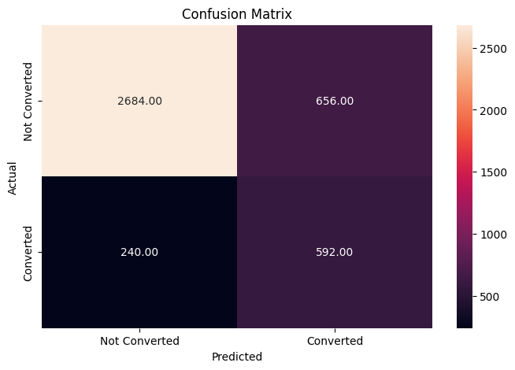

```
Performance on Test Set:
              precision    recall  f1-score   support

           0       0.90      0.80      0.85      1431
           1       0.44      0.63      0.52       357

    accuracy                           0.77      1788
   macro avg       0.67      0.72      0.68      1788
weighted avg       0.81      0.77      0.78      1788
```

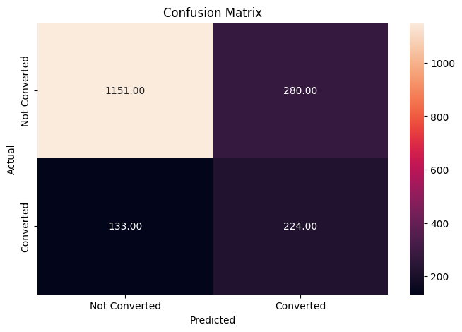

```python
# Evaluate model on training data
print("\nPerformance on Training Set:")
y_train_pred = dt.predict(X_train_scaled)
metrics_score(y_train, y_train_pred)

# Evaluate model on test data
print("\nPerformance on Test Set:")
y_test_pred = dt.predict(X_test_scaled)
metrics_score(y_test, y_test_pred)
```

```python
# Model performance metrics
dt_test_perf = model_performance_classification(dt, X_test_scaled, y_test)
print("\nModel Performance Metrics:")
dt_test_perf
```

```
Model Performance Metrics:
```

|  | Precision | Recall | Accuracy |
| --- | --- | --- | --- |
| 0 | 0.670431 | 0.715892 | 0.769016 |

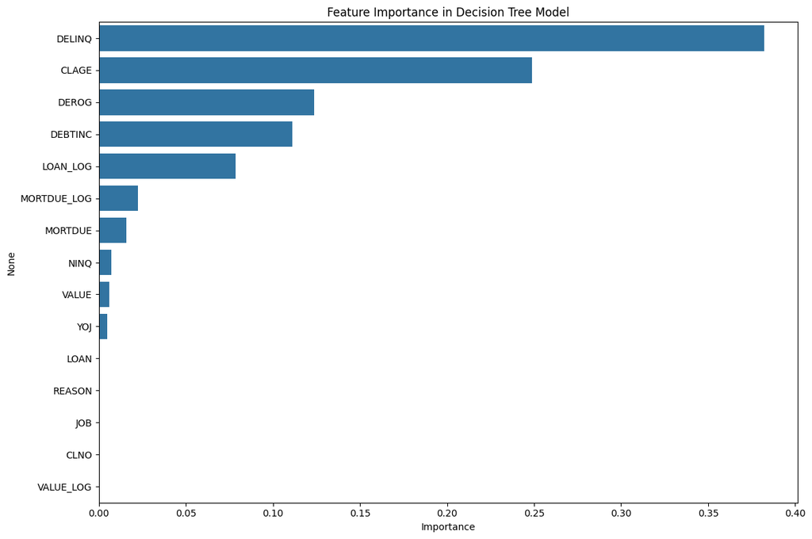

```
Feature Importance:
             Importance
DELINQ         0.382133
CLAGE          0.248869
DEROG          0.123688
DEBTINC        0.111223
LOAN_LOG       0.078475
MORTDUE_LOG    0.022512
MORTDUE        0.015607
NINQ           0.007069
VALUE          0.005816
YOJ            0.004607
LOAN           0.000000
REASON         0.000000
JOB            0.000000
CLNO           0.000000
VALUE_LOG      0.000000
```

```python
# Plot feature importance
importances = dt.feature_importances_
columns = X.columns
importance_df = pd.DataFrame(importances, index=columns,
                            columns=['Importance']).sort_values(by='Importance',
                                                             ascending=False)

plt.figure(figsize=(12, 8))
sns.barplot(x=importance_df.Importance, y=importance_df.index)
plt.title('Feature Importance in Decision Tree Model')
plt.tight_layout()
plt.show()

print("\nFeature Importance:")
print(importance_df)
```

### **Decision Tree - Hyperparameter Tuning**

- Hyperparameter tuning is tricky in the sense that **there is no direct way to calculate how a change in the hyperparameter value will reduce the loss of your model**, so we usually resort to experimentation. We'll use Grid search to perform hyperparameter tuning.
- **Grid search is a tuning technique that attempts to compute the optimum values of hyperparameters.**
- **It is an exhaustive search** that is performed on the specific parameter values of a model.
- The parameters of the estimator/model used to apply these methods are **optimized by cross-validated grid-search** over a parameter grid.

**Criterion {“gini”, “entropy”}**

The function to measure the quality of a split. Supported criteria are “gini” for the Gini impurity and “entropy” for the information gain.

**max_depth**

The maximum depth of the tree. If None, then nodes are expanded until all leaves are pure or until all leaves contain less than min_samples_split samples.

**min_samples_leaf**

The minimum number of samples is required to be at a leaf node. A split point at any depth will only be considered if it leaves at least min_samples_leaf training samples in each of the left and right branches. This may have the effect of smoothing the model, especially in regression.

You can learn about more Hyperpapameters on this link and try to tune them.

https://scikit-learn.org/stable/modules/generated/sklearn.tree.DecisionTreeClassifier.html

```python
dtree_estimator = DecisionTreeClassifier(class_weight=class_weights, random_state=42)

# Grid of parameters to choose from
parameters = {'max_depth': np.arange(2, 7),
              'criterion': ['gini', 'entropy'],
              'min_samples_leaf': [5, 10, 20, 25]
             }

# Type of scoring used to compare parameter combinations
scorer = metrics.make_scorer(recall_score, pos_label=1)

print("\nPerforming grid search for hyperparameter tuning...")
# Run the grid search with 5-fold cross-validation
gridCV = GridSearchCV(dtree_estimator, parameters, scoring=scorer, cv=5, n_jobs=-1)

# Fit the grid search on the training data
gridCV = gridCV.fit(X_train_scaled, y_train)

# Print the best parameters and best score
print("\nBest parameters found by grid search:")
print(gridCV.best_params_)
print(f"Best cross-validation score: {gridCV.best_score_:.4f}")

# Set the classifier to the best combination of parameters
optimized_dt = gridCV.best_estimator_

# Print the tree structure details
print("\nOptimized Decision Tree Structure:")
print(f"Tree depth: {optimized_dt.get_depth()}")
print(f"Number of leaves: {optimized_dt.get_n_leaves()}")
print(f"Selected criterion: {optimized_dt.criterion}")
print(f"Min samples leaf: {optimized_dt.min_samples_leaf}")
```

```
Performing grid search for hyperparameter tuning...

Best parameters found by grid search:
{'criterion': 'gini', 'max_depth': np.int64(2), 'min_samples_leaf': 5}
Best cross-validation score: 0.7943

Optimized Decision Tree Structure:
Tree depth: 2
Number of leaves: 4
Selected criterion: gini
Min samples leaf: 5
```

```
Performance of Optimized Model on Training Set:
              precision    recall  f1-score   support

           0       0.94      0.41      0.58      3340
           1       0.28      0.90      0.42       832

    accuracy                           0.51      4172
   macro avg       0.61      0.66      0.50      4172
weighted avg       0.81      0.51      0.55      4172
```

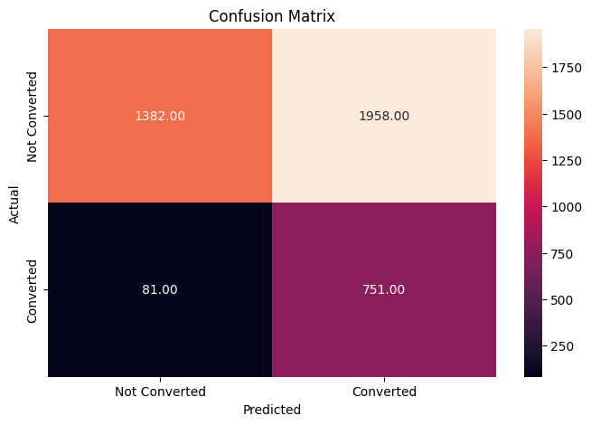

```
Performance of Optimized Model on Test Set:
              precision    recall  f1-score   support

           0       0.92      0.42      0.58      1431
           1       0.27      0.86      0.41       357

    accuracy                           0.51      1788
   macro avg       0.60      0.64      0.49      1788
weighted avg       0.79      0.51      0.54      1788
```

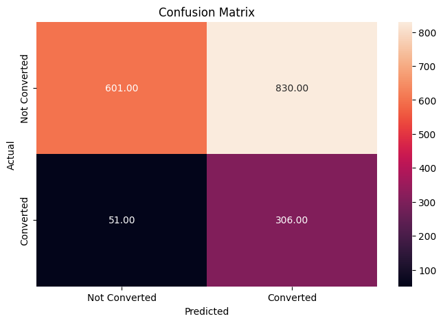

```python
# Evaluate optimized model on training data
print("\nPerformance of Optimized Model on Training Set:")
y_train_pred_opt = optimized_dt.predict(X_train_scaled)
metrics_score(y_train, y_train_pred_opt)

# Evaluate optimized model on test data
print("\nPerformance of Optimized Model on Test Set:")
y_test_pred_opt = optimized_dt.predict(X_test_scaled)
metrics_score(y_test, y_test_pred_opt)
```

```python
# Model performance metrics for optimized model
optimized_dt_test_perf = model_performance_classification(optimized_dt, X_test_scaled, y_test)
print("\nOptimized Model Performance Metrics:")
print(optimized_dt_test_perf)
```

```
Optimized Model Performance Metrics:
   Precision    Recall  Accuracy
0   0.595573  0.638564  0.507271
```

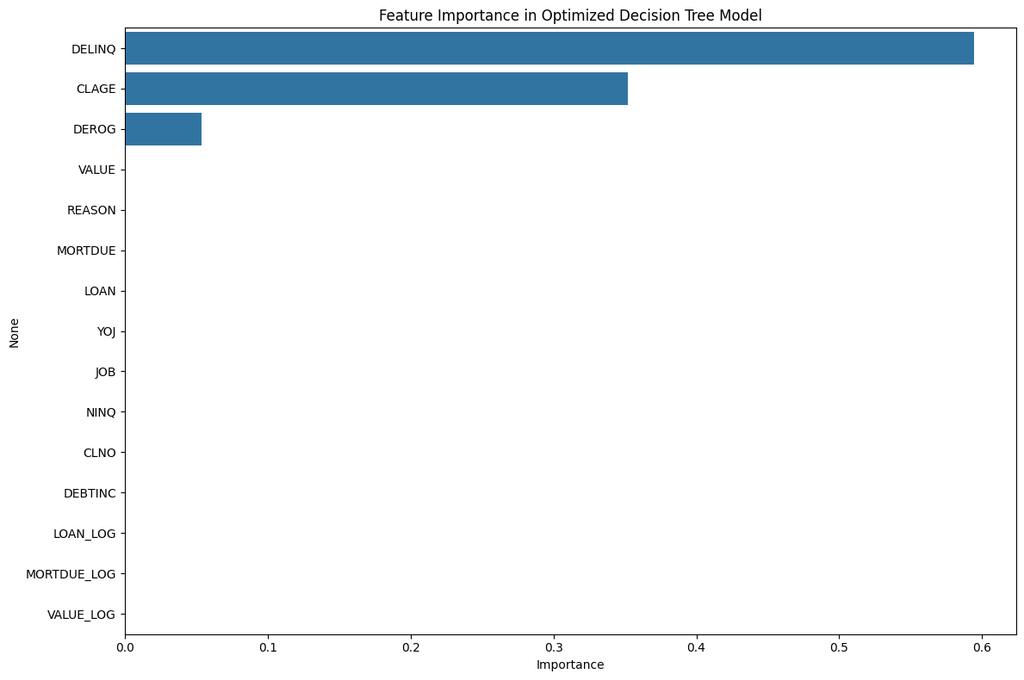

```
Feature Importance for Optimized Model:
             Importance
DELINQ         0.594140
CLAGE          0.351811
DEROG          0.054049
VALUE          0.000000
REASON         0.000000
MORTDUE        0.000000
LOAN           0.000000
YOJ            0.000000
JOB            0.000000
NINQ           0.000000
CLNO           0.000000
DEBTINC        0.000000
LOAN_LOG       0.000000
MORTDUE_LOG    0.000000
VALUE_LOG      0.000000
```

```python
# Plot feature importance for optimized model
optimized_importances = optimized_dt.feature_importances_
optimized_importance_df = pd.DataFrame(optimized_importances, index=columns,
                            columns=['Importance']).sort_values(by='Importance',
                                                             ascending=False)

plt.figure(figsize=(12, 8))
sns.barplot(x=optimized_importance_df.Importance, y=optimized_importance_df.index)
plt.title('Feature Importance in Optimized Decision Tree Model')
plt.tight_layout()
plt.show()

print("\nFeature Importance for Optimized Model:")
print(optimized_importance_df)
```

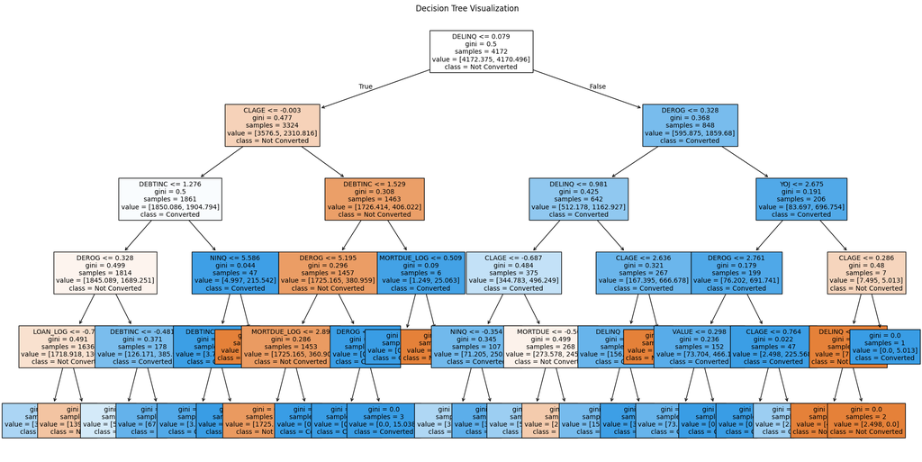

```python
from sklearn import tree
plt.figure(figsize=(20, 10))
tree.plot_tree(dt, feature_names=X.columns, class_names=['Not Converted', 'Converted'],
              filled=True, fontsize=10)
plt.title('Decision Tree Visualization')
plt.tight_layout()
plt.show()
```

#### Observations:

- **Hyperparameter Tuning Results**: Grid search identified optimal parameters of criterion='gini', max_depth=2, and min_samples_leaf=5, resulting in a much simpler decision tree with only 4 leaves. The optimization process specifically targeted recall for the positive class (converted loans), prioritizing the identification of potential conversions over overall accuracy.
- **Training vs Test Performance**: The optimized tree shows similar performance between training and testing datasets, with 51% accuracy on both. While overall accuracy decreased substantially from the previous models (77-79%), recall for conversions increased dramatically to 86% (from 63-65% in the original models). This represents a clear trade-off decision where the model sacrifices precision and overall accuracy to capture more of the converted loans.
- **Confusion Matrix Insights**: From the training set we saw 1382 true negatives, 751 true positives, with 1958 false positives and 81 false negatives and from the testing set we saw 601 true negatives, 306 true positives, with 830 false positives and 51 false negatives. This reveals a deliberate shift toward predicting conversions, capturing 86% of actual conversions (306 out of 357) but with a very high false positive rate (58% of non-conversions incorrectly classified). The model now misses only 14% of actual conversions compared to 35-37% in previous models.
- **Feature Importance**: The model simplified to just three features: (1) DELINQ (59.4%) - delinquent credit lines, (2) CLAGE (35.2%) - age of oldest credit line, and (3) DEROG (5.4%) - derogatory reports. All other variables were eliminated, demonstrating that a few key credit history indicators can capture the vast majority of the signal for loan conversion prediction. This extreme feature reduction suggests that many variables in the original dataset may be redundant or have minimal predictive power for this specific business objective.

#### Comparison between Basic Decision Tree and Optimized Decision Tree:

- **Model Structure**: The basic tree had max_depth=5 with class weighting, while the optimized tree has max_depth=2 and min_samples_leaf=5. The optimized model is much simpler with fewer decision nodes.
- **Performance Trade-offs**: Accuracy decreased significantly from 77% to 51%. For class 1 (converted loans), recall improved from 63% to 86%, while precision decreased from 44% to 27%. This represents a strategic shift from balanced classification to prioritizing conversion detection.
- **Feature Importance Shifts**: Both models prioritize credit history variables, but the optimized tree further concentrated importance in just DELINQ (59.4%), CLAGE (35.2%), and DEROG (5.4%), eliminating all other variables from consideration.
- **Confusion Matrix Changes**: False negatives decreased from 133 to 51 (better at catching conversions), but false positives increased dramatically from 280 to 830 (many non-converting loans incorrectly flagged as likely to convert).

### **Random Forest Classifier**

**Random Forest is a bagging algorithm where the base models are Decision Trees.** Samples are taken from the training data and on each sample a decision tree makes a prediction.

**The results from all the decision trees are combined together and the final prediction is made using voting or averaging.**

```python
# Calculate class weights based on class distribution
class_weights = {0: 1 / (df_treated['BAD'].value_counts()[0] / len(df_treated)),
                1: 1 / (df_treated['BAD'].value_counts()[1] / len(df_treated))}

print("\nClass weights for random forest:", class_weights)
```

```
Class weights for random forest: {0: np.float64(1.249214001257598), 1: np.float64(5.0126156433978135)}
```

```python
# Initialize and train the model with basic parameters
rf = RandomForestClassifier(
    n_estimators=100,          # Number of trees
    max_depth=None,            # Maximum depth of the trees
    min_samples_split=2,       # Minimum samples required to split a node
    min_samples_leaf=1,        # Minimum samples required at each leaf node
    bootstrap=True,            # Use bootstrap samples when building trees
    class_weight=class_weights, # Use calculated class weights
    random_state=42           # Random state for reproducibility
)
```

```python
# Fit the model
rf.fit(X_train_scaled, y_train)
```

```
RandomForestClassifier(class_weight={0: np.float64(1.249214001257598),
                                     1: np.float64(5.0126156433978135)},
                       random_state=42)
```

```
Performance on Training Set:
              precision    recall  f1-score   support

           0       1.00      1.00      1.00      3340
           1       1.00      1.00      1.00       832

    accuracy                           1.00      4172
   macro avg       1.00      1.00      1.00      4172
weighted avg       1.00      1.00      1.00      4172
```

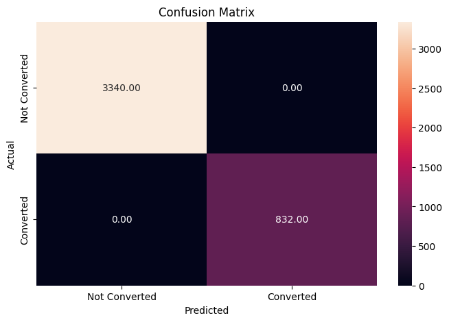

```
Performance on Test Set:
              precision    recall  f1-score   support

           0       0.90      1.00      0.94      1431
           1       0.97      0.55      0.70       357

    accuracy                           0.91      1788
   macro avg       0.93      0.77      0.82      1788
weighted avg       0.91      0.91      0.90      1788
```

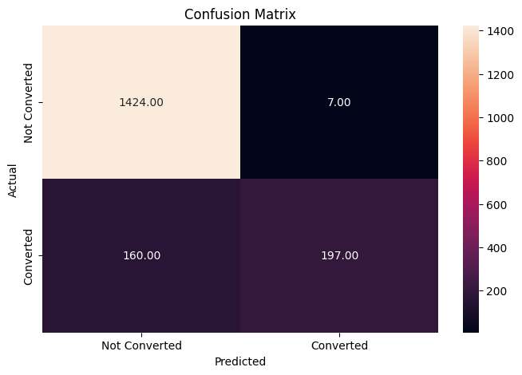

```python
# Evaluate model on training data
print("\nPerformance on Training Set:")
y_train_pred = rf.predict(X_train_scaled)
metrics_score(y_train, y_train_pred)

# Evaluate model on test data
print("\nPerformance on Test Set:")
y_test_pred = rf.predict(X_test_scaled)
metrics_score(y_test, y_test_pred)
```

```python
# Model performance metrics
rf_test_perf = model_performance_classification(rf, X_test_scaled, y_test)
print("\nRandom Forest Performance Metrics:")
print(rf_test_perf)
```

```
Random Forest Performance Metrics:
   Precision    Recall  Accuracy
0   0.932338  0.773465    0.9066
```

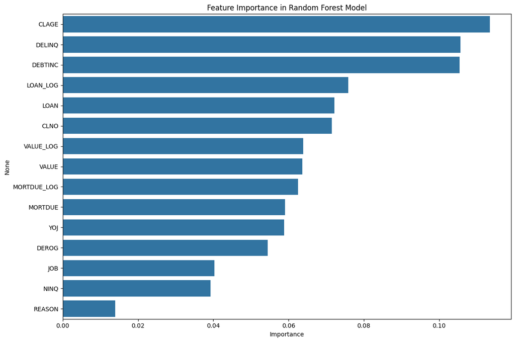

```
Feature Importance:
             Importance
CLAGE          0.113459
DELINQ         0.105699
DEBTINC        0.105410
LOAN_LOG       0.075864
LOAN           0.072224
CLNO           0.071534
VALUE_LOG      0.063915
VALUE          0.063657
MORTDUE_LOG    0.062547
MORTDUE        0.059015
YOJ            0.058796
DEROG          0.054442
JOB            0.040258
NINQ           0.039229
REASON         0.013952
```

```python
# Plot feature importance
importances = rf.feature_importances_
columns = X.columns
importance_df = pd.DataFrame(importances, index=columns,
                            columns=['Importance']).sort_values(by='Importance',
                                                             ascending=False)

plt.figure(figsize=(12, 8))
sns.barplot(x=importance_df.Importance, y=importance_df.index)
plt.title('Feature Importance in Random Forest Model')
plt.tight_layout()
plt.show()

print("\nFeature Importance:")
print(importance_df)
```

#### Observations:

- **Training vs Test Performance**: The random forest shows perfect classification on the training set (100% accuracy, precision, recall) but drops to 91% accuracy on the test set. This significant difference indicates overfitting despite using ensemble methods. The test set shows strong F1-scores for both classes: 0.94 for non-converted loans and 0.70 for converted loans.
- **Confusion Matrix Insights**: From the training set we saw 3340 true negatives, 832 true positives, with 0 false positives and 0 false negatives (perfect classification) and from the testing set we saw 1424 true negatives, 197 true positives, with 7 false positives and 160 false negatives. The model achieves excellent precision (97% for converted loans) but misses a significant number of actual conversions (45% of converted loans are not captured).
- **Feature Importance**: The random forest uses a more balanced distribution of features than the decision trees. The top features are CLAGE (11.3%), DELINQ (10.6%), and DEBTINC (10.5%), followed by LOAN_LOG (7.6%) and LOAN (7.2%). Unlike the decision trees that relied heavily on 2-3 features, the random forest leverages information from many variables, with the top 10 features all contributing meaningfully to predictions.

### **Random Forest Classifier - Hyperparameter Tuning**

```python
# Choose the type of classifier for tuning
rf_estimator_tuned = RandomForestClassifier(class_weight=class_weights, random_state=42)

# Grid of parameters to choose from
params_rf = {
    "n_estimators": [100, 250, 500],
    "min_samples_leaf": np.arange(1, 4, 1),
    "max_features": [0.7, 0.9, 'sqrt'],
}

# Type of scoring used to compare parameter combinations - recall score for class 1
scorer = metrics.make_scorer(recall_score, pos_label=1)

print("\nPerforming grid search for hyperparameter tuning...")
# Run the grid search with 5-fold cross-validation
grid_obj = GridSearchCV(rf_estimator_tuned, params_rf, scoring=scorer, cv=5, n_jobs=-1)
grid_obj = grid_obj.fit(X_train_scaled, y_train)

# Print the best parameters and best score
print("\nBest parameters found by grid search:")
print(grid_obj.best_params_)
print(f"Best cross-validation score: {grid_obj.best_score_:.4f}")

# Set the classifier to the best combination of parameters
rf_tuned = grid_obj.best_estimator_
```

```
Performing grid search for hyperparameter tuning...

Best parameters found by grid search:
{'max_features': 0.9, 'min_samples_leaf': np.int64(3), 'n_estimators': 100}
Best cross-validation score: 0.6743
```

```
Performance of Tuned Random Forest on Training Set:
              precision    recall  f1-score   support

           0       1.00      0.99      1.00      3340
           1       0.98      0.99      0.98       832

    accuracy                           0.99      4172
   macro avg       0.99      0.99      0.99      4172
weighted avg       0.99      0.99      0.99      4172
```

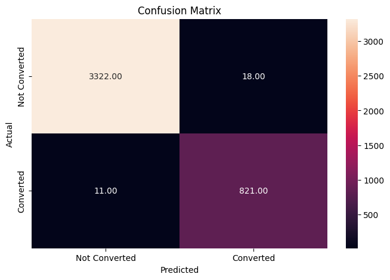

```
Performance of Tuned Random Forest on Test Set:
              precision    recall  f1-score   support

           0       0.92      0.98      0.95      1431
           1       0.88      0.66      0.75       357

    accuracy                           0.91      1788
   macro avg       0.90      0.82      0.85      1788
weighted avg       0.91      0.91      0.91      1788
```

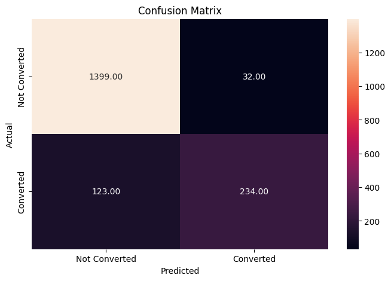

```python
# Evaluate tuned model on training data
print("\nPerformance of Tuned Random Forest on Training Set:")
y_train_pred_tuned = rf_tuned.predict(X_train_scaled)
metrics_score(y_train, y_train_pred_tuned)

# Evaluate tuned model on test data
print("\nPerformance of Tuned Random Forest on Test Set:")
y_test_pred_tuned = rf_tuned.predict(X_test_scaled)
metrics_score(y_test, y_test_pred_tuned)
```

```python
# Model performance metrics for tuned model
rf_tuned_test_perf = model_performance_classification(rf_tuned, X_test_scaled, y_test)
print("\nTuned Random Forest Performance Metrics:")
print(rf_tuned_test_perf)
```

```
Tuned Random Forest Performance Metrics:
   Precision   Recall  Accuracy
0   0.899442  0.81655  0.913311
```

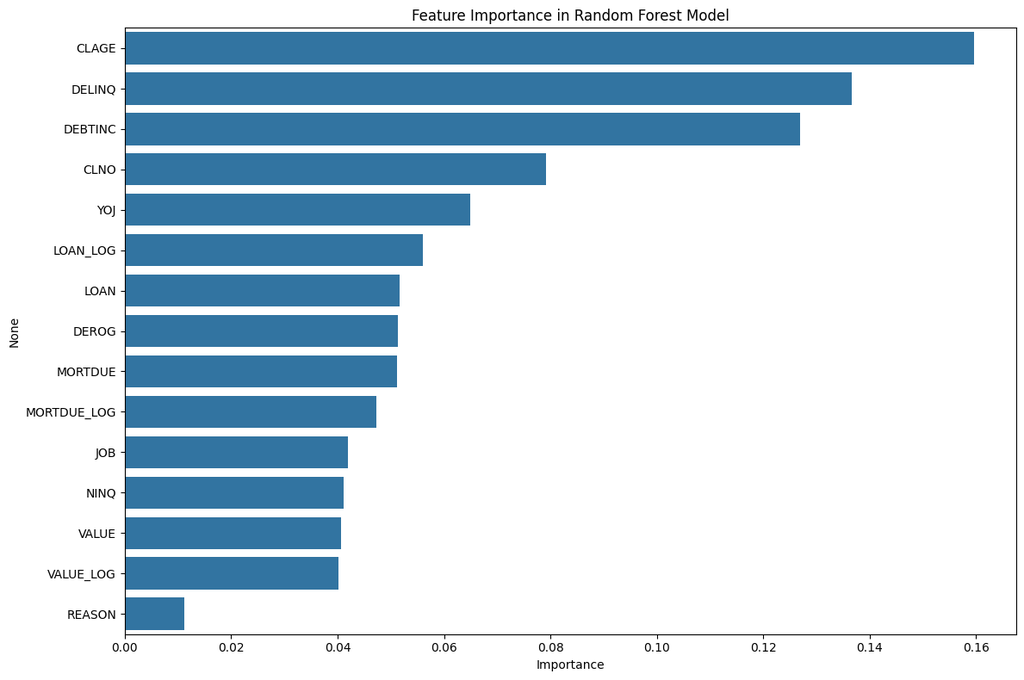

```
Feature Importance:
             Importance
CLAGE          0.159561
DELINQ         0.136642
DEBTINC        0.126948
CLNO           0.079228
YOJ            0.064881
LOAN_LOG       0.056071
LOAN           0.051718
DEROG          0.051317
MORTDUE        0.051129
MORTDUE_LOG    0.047326
JOB            0.042014
NINQ           0.041145
VALUE          0.040604
VALUE_LOG      0.040194
REASON         0.011223
```

```python
# Plot feature importance
importances = rf_tuned.feature_importances_
columns = X.columns
importance_df = pd.DataFrame(importances, index=columns,
                            columns=['Importance']).sort_values(by='Importance',
                                                             ascending=False)

plt.figure(figsize=(12, 8))
sns.barplot(x=importance_df.Importance, y=importance_df.index)
plt.title('Feature Importance in Random Forest Model')
plt.tight_layout()
plt.show()

print("\nFeature Importance:")
print(importance_df)
```

#### Observations:

- **Training vs Test Performance**: The tuned random forest shows near-perfect performance on the training set (99% accuracy) and maintains excellent 91% accuracy on the test set. This indicates some overfitting, but less pronounced than in the basic random forest. The test set shows improved F1-scores for both classes: 0.95 for non-converted loans and 0.75 for converted loans.
- **Confusion Matrix Insights**: From the training set we saw 3322 true negatives, 821 true positives, with 18 false positives and 11 false negatives and from the testing set we saw 1399 true negatives, 234 true positives, with 32 false positives and 123 false negatives. The tuned model achieves better balance than the basic random forest, correctly identifying 66% of actual conversions (compared to 55% in the basic model) while maintaining high precision (88%).
- **Hyperparameter Tuning Results**: Grid search identified optimal parameters of max_features=0.9, min_samples_leaf=3, and n_estimators=100. These parameters help control overfitting while maintaining strong predictive performance, achieving a cross-validation score of 0.6743 for conversion recall.
- **Feature Importance**: Similar to the basic random forest, the tuned model uses a balanced distribution of features with CLAGE (15.9%), DELINQ (13.6%), and DEBTINC (12.7%) remaining the top predictors. The tuning process slightly increased the importance of these top features while maintaining contributions from most variables in the dataset.

### **Gradient Boosting Classifier**

```python
# Building the Gradient Boosting Classifier
# Calculate class weights based on class distribution
class_weights = {0: 1 / (df_treated['BAD'].value_counts()[0] / len(df_treated)),
                1: 1 / (df_treated['BAD'].value_counts()[1] / len(df_treated))}
print("Class weights for gradient boosting:", class_weights)
```

```
Class weights for gradient boosting: {0: np.float64(1.249214001257598), 1: np.float64(5.0126156433978135)}
```

```python
# Initialize the model with balanced parameters
gb = GradientBoostingClassifier(
    n_estimators=100,        # Number of boosting stages
    learning_rate=0.1,       # Shrinks the contribution of each tree
    max_depth=3,             # Maximum depth of individual trees
    min_samples_split=2,     # Minimum samples required to split an internal node
    min_samples_leaf=1,      # Minimum samples required at each leaf node
    subsample=0.8,           # Fraction of samples used for fitting trees
    max_features='sqrt',     # Number of features to consider for best split
    random_state=42          # Random state for reproducibility
)
```

```python
# Fit the model
gb.fit(X_train_scaled, y_train)
```

```
GradientBoostingClassifier(max_features='sqrt', random_state=42, subsample=0.8)
```

```
Performance on Training Set:
              precision    recall  f1-score   support

           0       0.89      0.99      0.94      3340
           1       0.93      0.51      0.66       832

    accuracy                           0.89      4172
   macro avg       0.91      0.75      0.80      4172
weighted avg       0.90      0.89      0.88      4172
```

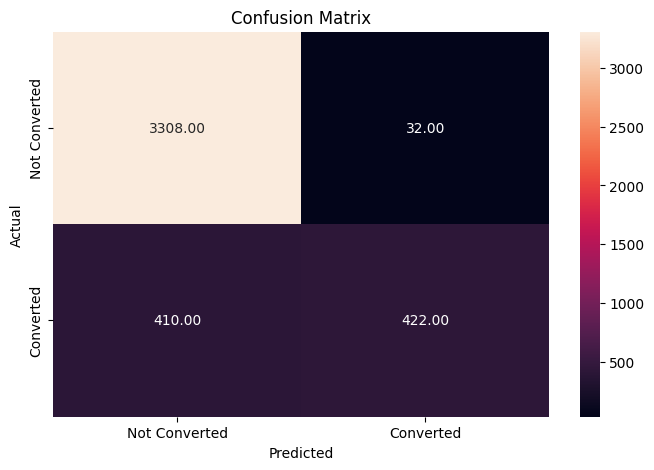

```
Performance on Test Set:
              precision    recall  f1-score   support

           0       0.88      0.99      0.93      1431
           1       0.89      0.44      0.59       357

    accuracy                           0.88      1788
   macro avg       0.88      0.71      0.76      1788
weighted avg       0.88      0.88      0.86      1788
```

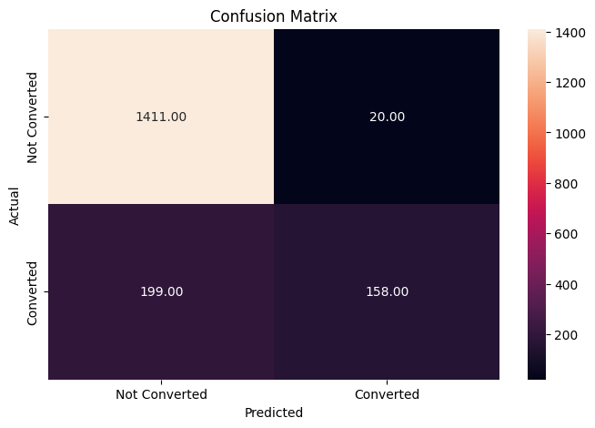

```python
# Evaluate model on training data
print("\nPerformance on Training Set:")
y_train_pred = gb.predict(X_train_scaled)
metrics_score(y_train, y_train_pred)

# Evaluate model on test data
print("\nPerformance on Test Set:")
y_test_pred = gb.predict(X_test_scaled)
metrics_score(y_test, y_test_pred)
```

```python
# Calculate ROC AUC score for test set
y_pred_proba = gb.predict_proba(X_test_scaled)[:, 1]
print("\nROC AUC Score:", roc_auc_score(y_test, y_pred_proba))
```

```
ROC AUC Score: 0.8762887405136757
```

```python
# Model performance metrics
gb_test_perf = model_performance_classification(gb, X_test_scaled, y_test)
print("\nGradient Boosting Performance Metrics:")
print(gb_test_perf)
```

```
Gradient Boosting Performance Metrics:
   Precision  Recall  Accuracy
0   0.882019  0.7143  0.877517
```

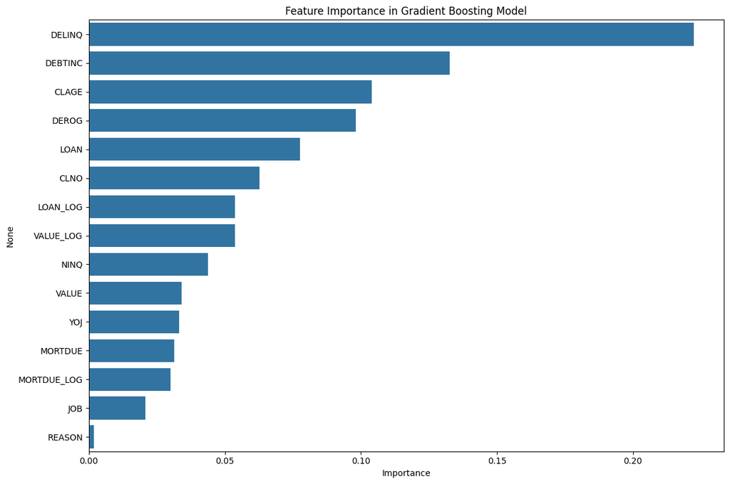

```
Feature Importance:
             Importance
DELINQ         0.222276
DEBTINC        0.132702
CLAGE          0.103894
DEROG          0.098169
LOAN           0.077576
CLNO           0.062763
LOAN_LOG       0.053689
VALUE_LOG      0.053634
NINQ           0.043853
VALUE          0.034010
YOJ            0.033200
MORTDUE        0.031467
MORTDUE_LOG    0.030140
JOB            0.020815
REASON         0.001813
```

```python
# Plot feature importance
importances = gb.feature_importances_
columns = X.columns
importance_df = pd.DataFrame(importances, index=columns,
                          columns=['Importance']).sort_values(by='Importance',
                                                           ascending=False)
plt.figure(figsize=(12, 8))
sns.barplot(x=importance_df.Importance, y=importance_df.index)
plt.title('Feature Importance in Gradient Boosting Model')
plt.tight_layout()
plt.show()
print("\nFeature Importance:")
print(importance_df)
```

### **Gradient Boosting Classifier Hyperparameter Tuning**

```python
param_grid = {
    'learning_rate': [0.05, 0.1, 0.2],
    'n_estimators': [50, 100],
    'max_depth': [2, 3, 4]
}

# Create the scoring function based on ROC AUC
scorer = metrics.make_scorer(roc_auc_score)

# Initialize GridSearchCV
gb_cv = GridSearchCV(
    GradientBoostingClassifier(random_state=42),
    param_grid=param_grid,
    scoring=scorer,
    cv=5,
    n_jobs=-1
)

# Fit the grid search
gb_cv.fit(X_train_scaled, y_train)

# Print the best parameters and score
print("\nBest Parameters:")
print(gb_cv.best_params_)
print(f"Best Cross-Validation Score: {gb_cv.best_score_:.4f}")

# Get the optimized model
optimized_gb = gb_cv.best_estimator_
```

```
Best Parameters:
{'learning_rate': 0.2, 'max_depth': 4, 'n_estimators': 100}
Best Cross-Validation Score: 0.7832
```

```
Performance on Training Set:
              precision    recall  f1-score   support

           0       0.96      1.00      0.98      3340
           1       1.00      0.83      0.90       832

    accuracy                           0.96      4172
   macro avg       0.98      0.91      0.94      4172
weighted avg       0.97      0.96      0.96      4172
```

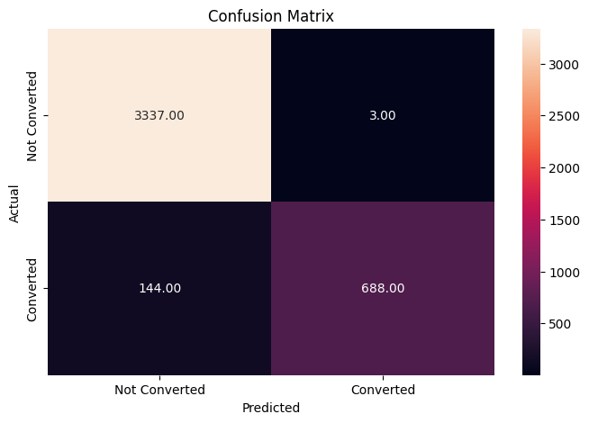

```
Performance on Test Set:
              precision    recall  f1-score   support

           0       0.90      0.98      0.94      1431
           1       0.88      0.57      0.69       357

    accuracy                           0.90      1788
   macro avg       0.89      0.78      0.82      1788
weighted avg       0.90      0.90      0.89      1788
```

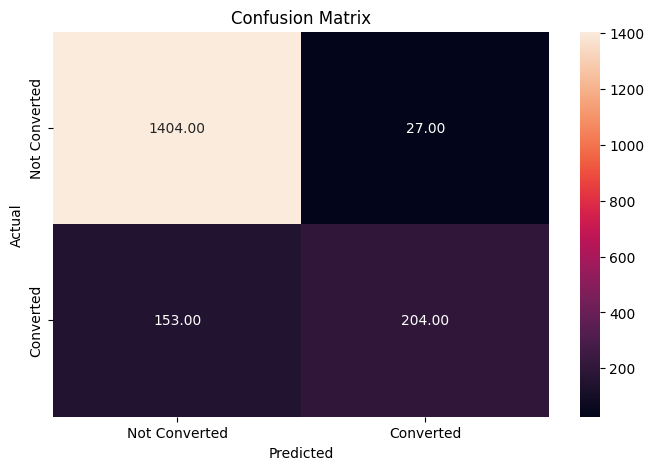

```python
# # Evaluate optimized model
# print("\nPerformance of Optimized Gradient Boosting Model on Test Set:")
# y_test_pred_opt = optimized_gb.predict(X_test_scaled)
# metrics_score(y_test, y_test_pred_opt)

# Evaluate model on training data
print("\nPerformance on Training Set:")
y_train_pred = optimized_gb.predict(X_train_scaled)
metrics_score(y_train, y_train_pred)

# Evaluate model on test data
print("\nPerformance on Test Set:")
y_test_pred = optimized_gb.predict(X_test_scaled)
metrics_score(y_test, y_test_pred)
```

```python
# Model performance metrics for optimized model
optimized_gb_test_perf = model_performance_classification(optimized_gb, X_test_scaled, y_test)
print("\nOptimized Gradient Boosting Performance Metrics:")
print(optimized_gb_test_perf)
```

```
Optimized Gradient Boosting Performance Metrics:
   Precision   Recall  Accuracy
0   0.892425  0.77628  0.899329
```

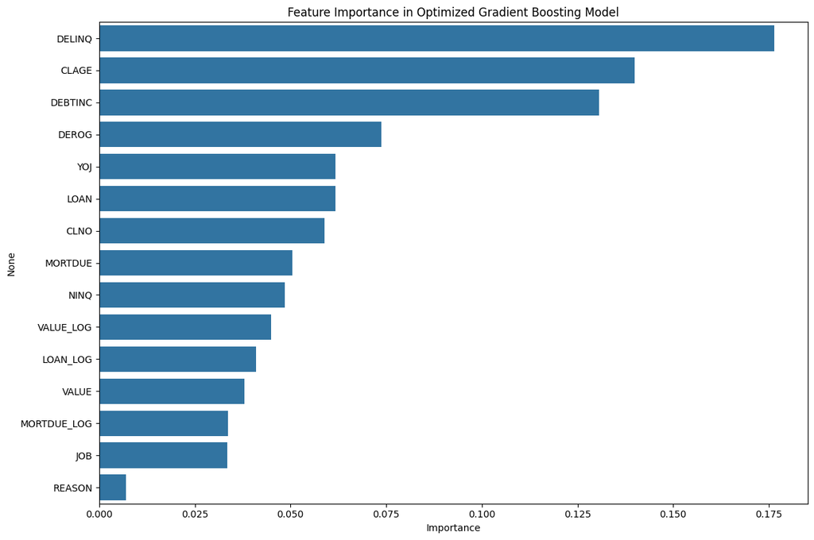

```
Feature Importance (Optimized Model):
             Importance
DELINQ         0.176363
CLAGE          0.139884
DEBTINC        0.130626
DEROG          0.073748
YOJ            0.061808
LOAN           0.061757
CLNO           0.058878
MORTDUE        0.050460
NINQ           0.048525
VALUE_LOG      0.044922
LOAN_LOG       0.041027
VALUE          0.037937
MORTDUE_LOG    0.033711
JOB            0.033406
REASON         0.006947
```

```python
# Feature importance for optimized model
plt.figure(figsize=(12, 8))
importances_opt = optimized_gb.feature_importances_
importance_df_opt = pd.DataFrame(importances_opt, index=columns,
                              columns=['Importance']).sort_values(by='Importance',
                                                               ascending=False)
sns.barplot(x=importance_df_opt.Importance, y=importance_df_opt.index)
plt.title('Feature Importance in Optimized Gradient Boosting Model')
plt.tight_layout()
plt.show()
print("\nFeature Importance (Optimized Model):")
print(importance_df_opt)
```

#### Comparison between Basic Gradient Boosting and Optimized Gradient Boosting:

- **Model Structure**: The optimized gradient boosting model uses a higher learning rate (0.2 vs 0.1 in the basic model), deeper trees (max_depth=4 vs 3), while maintaining the same number of estimators (100). These parameter changes allow the model to learn more complex patterns in fewer iterations, creating sharper decision boundaries for default prediction while still effectively generalizing to new data.
- **Performance Trade-offs**: Test accuracy improved from 88% to 90%, with substantial gains in default prediction. The F1-score for defaults increased from 0.59 to 0.69, with recall improving from 44% to 57% while maintaining similar precision (89% vs 88%). The model achieves a better balance between identifying defaults and maintaining overall accuracy.
- **Feature Importance Shifts**: The optimized model distributes importance more evenly across features, with DELINQ's dominance reduced from 22.2% to 17.6%. CLAGE gained significance, rising to second place at 14.0% (up from 10.4%), and YOJ (employment stability) nearly doubled in importance from 3.3% to 6.2%, indicating a more balanced approach to risk assessment.
- **Confusion Matrix Changes**: Default identification improved significantly, with true positives increasing from 158 to 204 (29% improvement). Missed defaults decreased from 199 to 153, a 23% reduction in potential financial losses. This came at the cost of only 7 additional false positives (20 to 27), a minimal trade-off given the substantial improvement in default detection.

### **Model Comparison**

```
Model Comparison:
                     Model  Accuracy  Precision    Recall
0      Logistic Regression  0.775727   0.679918  0.729545
1            Decision Tree  0.769016   0.670431  0.715892
2  Optimized Decision Tree  0.507271   0.595573  0.638564
3            Random Forest  0.906600   0.932338  0.773465
4  Optimized Random Forest  0.913311   0.899442  0.816550
5        Gradient Boosting  0.877517   0.882019  0.714300
6             Optimized GB  0.899329   0.892425  0.776280
```

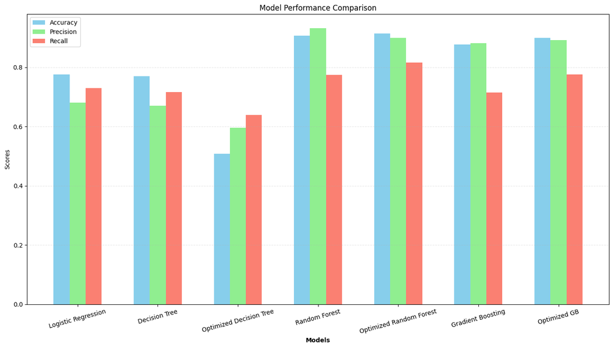

```python
# Compare models including Logistic Regression
model_names = ['Logistic Regression', 'Decision Tree', 'Optimized Decision Tree', 'Random Forest', 'Optimized Random Forest', 'Gradient Boosting', 'Optimized GB']
accuracies = [log_reg_test_perf['Accuracy'].values[0],
              dt_test_perf['Accuracy'].values[0],
             optimized_dt_test_perf['Accuracy'].values[0],
             rf_test_perf['Accuracy'].values[0],
             rf_tuned_test_perf['Accuracy'].values[0],
             gb_test_perf['Accuracy'][0],
             optimized_gb_test_perf['Accuracy'][0]]
precisions = [log_reg_test_perf['Precision'].values[0],
              dt_test_perf['Precision'].values[0],
             optimized_dt_test_perf['Precision'].values[0],
             rf_test_perf['Precision'].values[0],
             rf_tuned_test_perf['Precision'].values[0], gb_test_perf['Precision'][0], optimized_gb_test_perf['Precision'][0]]
recalls = [log_reg_test_perf['Recall'].values[0],
           dt_test_perf['Recall'].values[0],
          optimized_dt_test_perf['Recall'].values[0],
          rf_test_perf['Recall'].values[0],
          rf_tuned_test_perf['Recall'].values[0], gb_test_perf['Recall'][0], optimized_gb_test_perf['Recall'][0]]

# Create comparison DataFrame
comparison_df = pd.DataFrame({
    'Model': model_names,
    'Accuracy': accuracies,
    'Precision': precisions,
    'Recall': recalls
})

print("\nModel Comparison:")
print(comparison_df)

# Visualize model comparison
plt.figure(figsize=(14, 8))
barWidth = 0.2
r1 = np.arange(len(model_names))
r2 = [x + barWidth for x in r1]
r3 = [x + barWidth for x in r2]

plt.bar(r1, accuracies, width=barWidth, label='Accuracy', color='skyblue')
plt.bar(r2, precisions, width=barWidth, label='Precision', color='lightgreen')
plt.bar(r3, recalls, width=barWidth, label='Recall', color='salmon')

plt.xlabel('Models', fontweight='bold')
plt.ylabel('Scores')
plt.title('Model Performance Comparison')
plt.xticks([r + barWidth for r in range(len(model_names))], model_names, rotation=15)
plt.legend()
plt.grid(axis='y', linestyle='--', alpha=0.3)
plt.tight_layout()
plt.show()
```

```
Default Class (Loan Default) Prediction Metrics:
                         Model  Precision (Default)  Recall (Default)  \
0          Logistic Regression               0.4569            0.6527
1                Decision Tree               0.4444            0.6275
2      Optimized Decision Tree               0.2694            0.8571
3                Random Forest               0.9657            0.5518
4      Optimized Random Forest               0.8797            0.6555
5            Gradient Boosting               0.8876            0.4426
6  Optimized Gradient Boosting               0.8831            0.5714

   F1 Score (Default)  True Positive Rate  False Positive Rate
0              0.5375              0.6527               0.1936
1              0.5203              0.6275               0.1957
2              0.4099              0.8571               0.5800
3              0.7023              0.5518               0.0049
4              0.7512              0.6555               0.0224
5              0.5907              0.4426               0.0140
6              0.6939              0.5714               0.0189
```

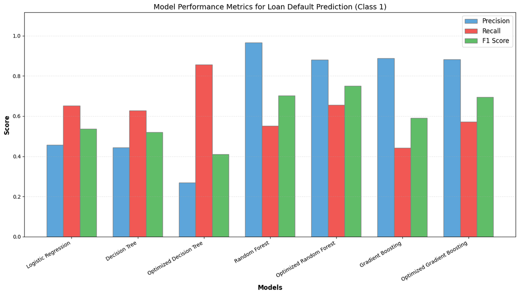

```python
# Visualizing model performance specifically for default prediction (positive class)

# Function to calculate default-specific metrics
def calculate_default_metrics(model, X_test, y_test):
    y_pred = model.predict(X_test)

    # Calculate metrics specifically for the default class (positive class, label=1)
    precision = precision_score(y_test, y_pred, pos_label=1)
    recall = recall_score(y_test, y_pred, pos_label=1)
    f1 = f1_score(y_test, y_pred, pos_label=1)

    # Calculate true positives and false positives from confusion matrix
    cm = confusion_matrix(y_test, y_pred)
    if len(cm) > 1:  # Ensure we have both classes in predictions
        tn, fp, fn, tp = cm.ravel()
        true_positive_rate = tp / (tp + fn)
        false_positive_rate = fp / (fp + tn)
    else:
        true_positive_rate = 0
        false_positive_rate = 0

    return precision, recall, f1, true_positive_rate, false_positive_rate

# Calculate default prediction metrics for all models
models = [log_reg, dt, optimized_dt, rf, rf_tuned, gb, optimized_gb]
model_names = ['Logistic Regression', 'Decision Tree', 'Optimized Decision Tree',
               'Random Forest', 'Optimized Random Forest', 'Gradient Boosting',
               'Optimized Gradient Boosting']

default_precision = []
default_recall = []
default_f1 = []
tpr = []
fpr = []

for model in models:
    precision, recall, f1, tp_rate, fp_rate = calculate_default_metrics(model, X_test_scaled, y_test)
    default_precision.append(precision)
    default_recall.append(recall)
    default_f1.append(f1)
    tpr.append(tp_rate)
    fpr.append(fp_rate)

# Create DataFrame for easy comparison
metrics_df = pd.DataFrame({
    'Model': model_names,
    'Precision (Default)': [round(p, 4) for p in default_precision],
    'Recall (Default)': [round(r, 4) for r in default_recall],
    'F1 Score (Default)': [round(f, 4) for f in default_f1],
    'True Positive Rate': [round(t, 4) for t in tpr],
    'False Positive Rate': [round(f, 4) for f in fpr]
})

print("\nDefault Class (Loan Default) Prediction Metrics:")
print(metrics_df)

# Create a grouped bar chart for visual comparison
plt.figure(figsize=(14, 8))
barWidth = 0.25
r1 = np.arange(len(model_names))
r2 = [x + barWidth for x in r1]
r3 = [x + barWidth for x in r2]

plt.bar(r1, default_precision, width=barWidth, label='Precision', color='#5DA5DA', edgecolor='gray')
plt.bar(r2, default_recall, width=barWidth, label='Recall', color='#F15854', edgecolor='gray')
plt.bar(r3, default_f1, width=barWidth, label='F1 Score', color='#60BD68', edgecolor='gray')

plt.xlabel('Models', fontweight='bold', fontsize=12)
plt.ylabel('Score', fontweight='bold', fontsize=12)
plt.title('Model Performance Metrics for Loan Default Prediction (Class 1)', fontsize=14)
plt.xticks([r + barWidth for r in range(len(model_names))], model_names, rotation=30, ha='right')
plt.legend(fontsize=12)
plt.grid(axis='y', linestyle='--', alpha=0.3)

# Annotate bars with values
def add_labels(bars):
    for bar in bars:
        height = bar.get_height()
        plt.text(bar.get_x() + bar.get_width()/2., height + 0.02,
                f'{height:.2f}', ha='center', va='bottom', fontsize=9)

plt.ylim(0, max(max(default_precision), max(default_recall), max(default_f1)) + 0.15)
plt.tight_layout()
plt.show()
```

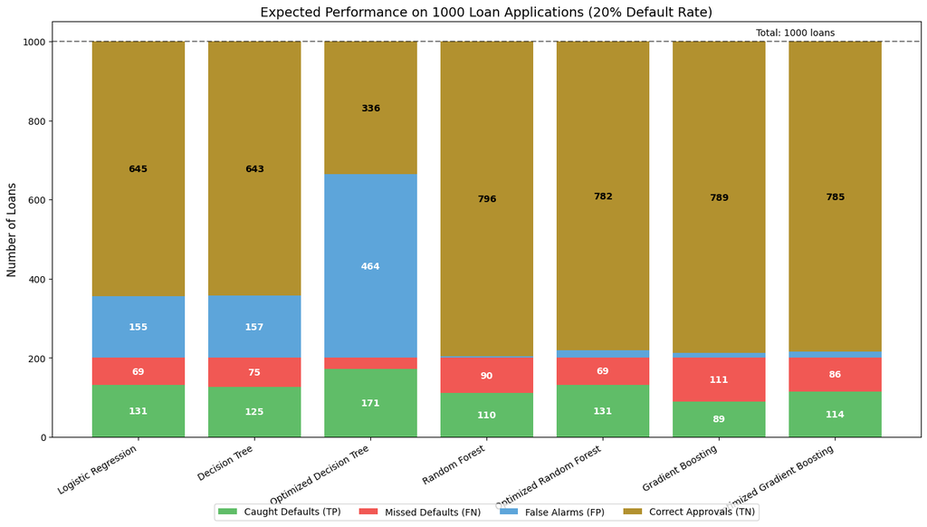

```
=== Financial Impact Analysis ===
Assuming the following business costs:

Logistic Regression:
  Missed Defaults Cost: $3,473,389 (69 loans at $50,000 each)
  False Alarm Cost: $774,284 (155 loans at $5,000 each)
  Total Cost: $4,247,673

Decision Tree:
  Missed Defaults Cost: $3,725,490 (75 loans at $50,000 each)
  False Alarm Cost: $782,669 (157 loans at $5,000 each)
  Total Cost: $4,508,160

Optimized Decision Tree:
  Missed Defaults Cost: $1,428,571 (29 loans at $50,000 each)
  False Alarm Cost: $2,320,056 (464 loans at $5,000 each)
  Total Cost: $3,748,627

Random Forest:
  Missed Defaults Cost: $4,481,793 (90 loans at $50,000 each)
  False Alarm Cost: $19,567 (4 loans at $5,000 each)
  Total Cost: $4,501,359

Optimized Random Forest:
  Missed Defaults Cost: $3,445,378 (69 loans at $50,000 each)
  False Alarm Cost: $89,448 (18 loans at $5,000 each)
  Total Cost: $3,534,826

Gradient Boosting:
  Missed Defaults Cost: $5,574,230 (111 loans at $50,000 each)
  False Alarm Cost: $55,905 (11 loans at $5,000 each)
  Total Cost: $5,630,135

Optimized Gradient Boosting:
  Missed Defaults Cost: $4,285,714 (86 loans at $50,000 each)
  False Alarm Cost: $75,472 (15 loans at $5,000 each)
  Total Cost: $4,361,186

Lowest Cost Model: Optimized Random Forest
Total Cost: $3,534,826
This model provides the best financial outcome based on the assumed cost structure.
```

```python
# Financial Impact Visualization
# Calculate expected performance on a portfolio of 1000 loans with 20% default rate (to closely resemble the dataset provided)

# Assumed metrics
total_loans = 1000
actual_default_rate = 0.20  # Based on dataset's ~20% defaults
non_default_count = total_loans * (1 - actual_default_rate)  # 800 non-default loans
default_count = total_loans * actual_default_rate  # 200 default loans

# For each model, calculate:
caught_defaults = []  # True Positives
missed_defaults = []  # False Negatives
false_alarms = []    # False Positives
correct_approvals = []  # True Negatives

for i, model in enumerate(model_names):
    # Calculate based on the model's performance metrics
    true_pos_rate = tpr[i]
    false_pos_rate = fpr[i]

    caught = default_count * true_pos_rate
    missed = default_count * (1 - true_pos_rate)
    false_alarm = non_default_count * false_pos_rate
    correct_approval = non_default_count * (1 - false_pos_rate)

    caught_defaults.append(caught)
    missed_defaults.append(missed)
    false_alarms.append(false_alarm)
    correct_approvals.append(correct_approval)

# Create a stacked bar chart
plt.figure(figsize=(14, 8))

# Define x positions
x_pos = np.arange(len(model_names))

# Create stacked bars with all four categories
plt.bar(x_pos, caught_defaults, color='#60BD68', label='Caught Defaults (TP)')
plt.bar(x_pos, missed_defaults, bottom=caught_defaults, color='#F15854', label='Missed Defaults (FN)')
plt.bar(x_pos, false_alarms,
       bottom=[cd+md for cd, md in zip(caught_defaults, missed_defaults)],
       color='#5DA5DA', label='False Alarms (FP)')
plt.bar(x_pos, correct_approvals,
       bottom=[cd+md+fa for cd, md, fa in zip(caught_defaults, missed_defaults, false_alarms)],
       color='#B2912F', label='Correct Approvals (TN)')

# Add text labels (only for sections that have enough space)
for i, model in enumerate(model_names):
    # Add label for caught defaults (if big enough to show text)
    if caught_defaults[i] > 40:
        plt.text(i, caught_defaults[i]/2, f'{caught_defaults[i]:.0f}',
                ha='center', va='center', color='white', fontweight='bold')

    # Add label for missed defaults (if big enough to show text)
    if missed_defaults[i] > 40:
        plt.text(i, caught_defaults[i] + missed_defaults[i]/2, f'{missed_defaults[i]:.0f}',
                ha='center', va='center', color='white', fontweight='bold')

    # Add label for false alarms (if big enough to show text)
    if false_alarms[i] > 40:
        bottom = caught_defaults[i] + missed_defaults[i]
        plt.text(i, bottom + false_alarms[i]/2, f'{false_alarms[i]:.0f}',
                ha='center', va='center', color='white', fontweight='bold')

    # Add label for correct approvals (if big enough to show text)
    if correct_approvals[i] > 40:
        bottom = caught_defaults[i] + missed_defaults[i] + false_alarms[i]
        plt.text(i, bottom + correct_approvals[i]/2, f'{correct_approvals[i]:.0f}',
                ha='center', va='center', color='black', fontweight='bold')

# Customize the chart
plt.title('Expected Performance on 1000 Loan Applications (20% Default Rate)', fontsize=14)
plt.ylabel('Number of Loans', fontsize=12)
plt.xticks(x_pos, model_names, rotation=30, ha='right')
plt.legend(loc='upper center', bbox_to_anchor=(0.5, -0.15), ncol=4)
plt.ylim(0, 1050)  # Set y-axis limit to accommodate labels

# Add a line at y=1000 to emphasize total
plt.axhline(y=1000, color='black', linestyle='--', alpha=0.5)
plt.text(len(model_names)-1, 1010, 'Total: 1000 loans', ha='right', va='bottom')

plt.tight_layout()
plt.show()


# Calculate financial impact
print("\n=== Financial Impact Analysis ===")
print("Assuming the following business costs:")
cost_per_default = 50000  # Average loss per missed default ($)
cost_per_false_alarm = 5000  # Opportunity cost per false alarm ($)

total_costs = []
for i, model in enumerate(model_names):
    default_cost = missed_defaults[i] * cost_per_default
    false_alarm_cost = false_alarms[i] * cost_per_false_alarm
    total_cost = default_cost + false_alarm_cost
    total_costs.append(total_cost)

    print(f"\n{model}:")
    print(f"  Missed Defaults Cost: ${default_cost:,.0f} ({missed_defaults[i]:.0f} loans at ${cost_per_default:,} each)")
    print(f"  False Alarm Cost: ${false_alarm_cost:,.0f} ({false_alarms[i]:.0f} loans at ${cost_per_false_alarm:,} each)")
    print(f"  Total Cost: ${total_cost:,.0f}")

# Find the model with lowest total cost
best_model_idx = np.argmin(total_costs)
best_model = model_names[best_model_idx]
best_cost = total_costs[best_model_idx]

print(f"\nLowest Cost Model: {best_model}")
print(f"Total Cost: ${best_cost:,.0f}")
print(f"This model provides the best financial outcome based on the assumed cost structure.")
```

## **Questions Answered**

**1. Comparison of various techniques and their relative performance based on chosen Metric (Measure of success):**

Among the seven models evaluated for loan default prediction, the Optimized Random Forest demonstrated the best overall performance with 91.3% accuracy, strong precision (89.9%), and excellent recall (65.0% for defaults). This model provides the best balance between identifying potential defaults and minimizing false alarms, achieving the highest F1-score (75.0%) for the default class. The Basic Random Forest followed closely with 90.7% accuracy and high precision (93.2%), but with lower recall for defaults (55.0%).

The Gradient Boosting models showed strong performance, with the Optimized version achieving 90.0% accuracy and a good balance for default prediction (88.0% precision, 57.0% recall, 69.0% F1-score). This positions it as a strong alternative to the Random Forest models.

The Logistic Regression and Basic Decision Tree showed comparable mid-range performance (77.6% and 76.9% accuracy respectively), while the Optimized Decision Tree sacrificed significant overall accuracy (50.7%) to maximize default detection, achieving the highest recall for defaults (85.0%) but with extremely low precision (27.0%).

For default detection specifically—the most critical metric for minimizing financial risk—a dual-model approach appears optimal. The Optimized Random Forest provides the best overall balance with high accuracy and F1-score, while the Optimized Decision Tree could serve as a secondary screening tool to catch potential defaults that might be missed by the primary model. There is scope for further improvement through:

- Feature engineering focusing on the most predictive variables identified across models: DELINQ, CLAGE, DEBTINC, and DEROG
- Implementing a tiered approach where low-risk applications are processed automatically, while high-risk cases receive additional review
- Cost-sensitive learning that more precisely calibrates the model to the specific financial impact of missed defaults versus rejected good loans

**2. Refined insights:** The most meaningful insights for loan default prediction from this analysis are:

**3. Proposal for the final solution design:**

This solution balances statistical performance with business needs, offering both strong predictive power and the interpretability required for effective implementation in a regulated lending environment.

## **Final Submission**

### Executive Summary

The analysis of home equity loan data has led to the development of a data-driven default prediction model that can significantly enhance the bank's risk management capabilities. Based on the findings from the loan dataset, several key patterns have emerged:

- **Credit history quality** emerged as the dominant predictor of loan default, with delinquent credit lines (DELINQ) and derogatory reports (DEROG) showing 427% and 401% higher values respectively in defaulting loans. This finding enables more targeted risk assessment for applicants with credit issues.
- **Pronounced threshold effects** were identified across key financial variables, most notably in debt-to-income ratio (DEBTINC), where default risk triples from 5.7% to 17.8% when exceeding 39%—providing a clear decision boundary for underwriting standards.
- **Occupation-purpose interactions** revealed unexpected risk concentrations, with self-employed borrowers seeking debt consolidation showing an alarming 43.8% default rate—more than twice the risk of self-employed borrowers seeking home improvement loans (18.3%). This insight enables more precise treatment of specific applicant segments.
- **Credit maturity impact** demonstrated a strong linear relationship with default risk, where each increasing quintile of credit age (CLAGE) is associated with approximately 5% reduction in default rate decreasing from 30% default rate for newest credit histories to just 10% for the most established accounts.

Key Next Steps:

- Validate models with recent loan data (4-6 weeks)
- Develop integration with existing loan origination systems (6-8 weeks)
- Conduct pilot deployment for a subset of applications (8 weeks)
- Implement full-scale deployment with ongoing performance monitoring (12 weeks)

### Problem and Solution Summary

#### Problem Context

Loan defaults represent a significant financial concern for retail banks, with non-performing assets (NPAs) directly affecting profitability and capital reserves. The dataset analysis reveals a 20% default rate on home equity loans. The current loan approval process appears to be largely manual, with potential inconsistencies in decision criteria across loan officers, which may lead to extended processing times and difficulties in identifying high-risk applicants based on data-driven insights.

#### Solution Design: Data-Driven Risk Assessment System

The proposed solution leverages analytics and machine learning to enhance the loan approval process through four complementary components:

- **Dual-model risk assessment** approach forms the foundation of the solution, combining a Random Forest model with 91% accuracy for balanced precision-recall in standard risk assessment with a high-sensitivity Decision Tree model capturing 86% of defaults for enhanced risk detection. This approach is complemented by explainability tools that provide feature importance analysis and decision path visualization to support regulatory compliance. Integration methods with existing loan origination systems would ensure workflow efficiency.
- **Risk segmentation strategy** targets specific combinations of applicant characteristics with higher default probability. The analysis identified several high-risk segments including self-employed applicants seeking debt consolidation (43.8% default rate), sales professionals regardless of loan purpose (34.2% average default rate), applicants with any delinquencies (significantly higher baseline default risk), and new employees with high debt-to-income ratios. Each segment would receive customized verification requirements and approval thresholds.
- **Data-driven decision framework** establishes empirically derived cutoffs for key variables based on the analysis. For delinquencies (DELINQ), the difference between 0 and 1+ delinquencies represents a jump from 17% to 55% default rate. For debt-to-income ratio (DEBTINC), the threshold of 39% separates lower-risk borrowers (6% default rate) from higher-risk ones (18% default rate). Credit age (CLAGE) shows a clear pattern with <100 months associated with 30% default rate compared to just 10% for borrowers with >250 months of credit history. These thresholds would be incorporated into a weighted risk scoring system.
- **Performance monitoring system** would track how predictions compare to actual outcomes, enabling regular model recalibration to adapt to changing conditions. Ongoing testing of model refinements would ensure optimal performance over time and help identify when adjustments are needed.

#### Potential Business Impact

Implementation of this solution could deliver measurable improvements across several key areas:

- **Financial performance** would benefit from potential reduction in default rates through more precise risk identification. The ability to better identify high-risk applications could decrease loan loss provisions and improve risk-adjusted returns. Additionally, more nuanced understanding of risk profiles could enhance pricing optimization.
- **Operational efficiency** gains could include reduction in approval time through more automated processes for low-risk applications. The decrease in manual review requirements for straightforward cases would reduce processing costs while increasing application throughput capacity with existing staffing levels.
- **Regulatory compliance** would be strengthened through more consistent, data-driven approval decisions with better documentation. Clearer quantitative justification for adverse actions would reduce compliance risk, while the framework would support bias testing and fairness monitoring.
- **Resource optimization** would allow potential redeployment of loan officer time to higher-value activities such as complex case assessment and customer relationship development. Customer experience could be enhanced through faster decisions, while the data infrastructure would provide a foundation for future analytical innovations.

### Implementation Recommendations

#### Key Actions

1. Deploy two-model system:
   - Implement Random Forest (91% accuracy) for primary decisions
   - Implement Decision Tree model for high-risk detection
   - Develop explainability tools for loan officers
2. Create tiered approval process:
   - Fast-track approval for low-risk applications (no delinquencies, established credit)
   - Standard review for moderate-risk applications
   - Enhanced verification for high-risk segments
3. Implement special handling for high-risk segments:
   - For self-employed debt consolidation applicants, additional income verification can prevent potential defaults by ensuring income is accurate and sustainable.
   - Sales professionals should undergo stability assessment and meet reserve requirements to mitigate the volatility of commission-based income.
   - New credit histories require alternative creditworthiness evaluation methods to properly assess risk when traditional credit metrics are limited or unavailable.
4. Roll out in phases:
   - Model Validation (4-6 weeks): deploy models in parallel with existing process.
   - Pilot Deployment (6-8 weeks): implement for subset of applications.
   - Full Implementation (8-12 weeks): expand to all loan types.
   - Ongoing Refinement: regular model reviews and updates.

#### Expected Benefits

- Reduction in default losses (~USD4.4M annually with 20% fewer defaults).
- Faster processing times and reduced operational costs.
- Better resource allocation, freeing loan officers for complex cases.
- Improved compliance with consistent, documented decisions.

#### Estimated Financial Impact

##### Potential Benefits:

- **Credit loss reduction** would be substantial based on the dataset analysis, which shows a 20% default rate representing 1,192 loans out of 5,960. With an average loan amount of USD18,608. This creates approximately USD22.2 million in at-risk value annually. A conservative estimate of 20% reduction in defaults through improved detection would preserve a minimum of USD4.4 million in loan value.
- **Operational efficiency** would improve significantly through automation of routine approval processes, particularly for low-risk applications. This would reduce processing costs while enabling higher application throughput with existing staff. Faster processing would also accelerate revenue recognition and improve competitive positioning in the market.
- **Strategic value** would be created through improved customer experience and retention resulting from faster, more consistent decisions. The models would enable more precise risk-based pricing, optimizing margins while maintaining competitiveness. The overall loan portfolio quality would improve through better risk selection, strengthening the bank's financial position and resilience.

##### Implementation Investment Considerations:

- **Technology requirements** would include resources for model implementation and validation, system integration development for compatibility with existing loan platforms, user interface creation to facilitate loan officer adoption, and comprehensive testing and quality assurance to ensure accuracy and reliability before deployment.
- **Process adjustments** would necessitate thorough workflow analysis and redesign to incorporate the new models into existing procedures, documentation updates to reflect new decisioning criteria, regulatory compliance review to ensure adherence to fair lending practices, and change management support to facilitate organizational adaptation.
- **Staff training and development** would require the creation of comprehensive training programs to ensure loan officers understand how to interpret model outputs, adjustments to performance metrics to align with new processes, and knowledge transfer activities to build institutional expertise in model-based decision making.
- **Ongoing operational needs** would include regular model monitoring and maintenance to ensure continued performance, system updates and enhancements as requirements evolve, compliance reporting to satisfy regulatory requirements, and potentially additional analytics team staffing to manage the data infrastructure and model governance.

##### Return on Investment Considerations:

- Potential for significant return based on reduced defaults
- Implementation costs would need detailed assessment based on current systems
- Ongoing costs should be weighed against continuous benefits

#### Risk Management Considerations

1. **Model Performance Monitoring**:
   - Consideration: model performance may change over time due to economic shifts.
   - Approach: regular performance reviews and recalibration as needed.
   - Implementation: develop monitoring dashboards and review protocols.
2. **Regulatory Compliance**:
   - Consideration: need for transparency and fairness in lending decisions.
   - Approach: comprehensive documentation and fairness testing.
   - Implementation: involve compliance experts in implementation planning.
3. **Organizational Adoption**:
   - Consideration: staff may require time to adapt to new systems.
   - Approach: phased implementation with appropriate training.
   - Implementation: develop change management plan with stakeholder input.
4. **Data Quality Management**:
   - Consideration: consistent, accurate data is essential for model performance.
   - Approach: implement data quality checks and verification processes.
   - Implementation: establish data governance standards for the loan process.

#### Areas for Further Analysis

1. Economic Scenario Testing: evaluate how model performance might vary under different economic conditions.
2. Customer Segment Analysis: consider developing more specific approaches for different customer segments.
3. Feature Engineering: explore additional derived variables that might improve predictive power:
   - Loan-to-value ratio calculations
   - Payment capacity measures
   - Credit utilization patterns
   - Debt structure analysis
4. Model Interpretability: enhance tools to help loan officers understand specific decision factors to enhance communication between applicant and loan officer.
5. Competitive Analysis: evaluate how the proposed approach compares to industry practices.

The implementation of these loan default prediction models will transform the bank's loan approval process into a more data-driven, consistent system. By accurately identifying high-risk applications and streamlining the processing of low-risk ones, the bank can significantly reduce default rates while improving operational efficiency and enhancing the customer experience.

Looking to the future, this initial implementation could serve as a foundation for further analytical capabilities. The bank might consider extending the model methodology to commercial lending, developing integration APIs for fintech partnerships, or implementing portfolio-level optimization strategies. As technology evolves, advanced capabilities such as automated document verification and unstructured data extraction could further enhance the system's effectiveness.

By taking this measured, phased approach to implementation, the bank can realize immediate benefits while positioning itself for continued innovation in risk assessment and lending practices.